# Segmenting and Clustering Neighborhoods in HoChiMinh City

##### by Huynh Khanh Duy on 22-Feb-2020

## Introduction

Ho Chi Minh City, also known by its former name of Saigon, is the most populous city in Vietnam with a population more than ten million in. Located in southeastern Vietnam, the metropolis surrounds the Saigon River and covers about 2,061 square kilometres.

Ho Chi Minh City is economic heart of the nation and is classified as a Beta+ World City by Globalization and World Cities Research Network. It is home to the Ho Chi Minh City Stock Exchange, the largest stock exchange by total market capitalization in Vietnam and the headquarters of many national and international banks and companies.

As a major gateway to Vietnam, the city received over 8.6 million international visitors in 2019. Ho Chi Minh City accounted for about 22 percent of the national GDP and 29 percent its financial capital in 2018. As a result, brief information from data analysis on neighborhoods of the city can help visitors and investors to decide an interesting destination for their purpose.

## Objective

In this project, we will study in details the area classification using Foursquare data and machine learning segmentation and clustering. The aim of this project is to segment areas of Ho Chi Minh City based on the most common places captured from Foursquare. From this segmentation and clustering, a useful information about residential, tourism places, or others can be hopefully determined.

## Data acquisition and cleaning

List of Administrative Divisions of Vietnam can be obtained from the link: https://www.gso.gov.vn/dmhc2015/Default.aspx given by General Statistics Office of Vietnam. The list is saved under Excel format and can be imported as a Panda Dataframe.

Areas (or neighborhoods) of Ho Chi Minh City is then extracted from the List of Administrative Divisions of Vietnam. As the list contains all administrative divisions of the whole Vietnam, Pandas filtering functions are therefore applied to find only Wards and Districts of Ho Chi Minh City. In addition, after examination of the extracted data, it is found that some cells containing information on Wards of Ho Chi Minh City can lead to inexact geographical determination. For example, with name of a ward as number, it should be one digit if it is less than ten, e.g. "Phường 1" instead of "Phường 01". In addition of space character also is found in some cases. As a result, a minor correction should be carried out on the filtered dataframe followed by an addition of the column named "Area" which is composed from the relevant data from the column "Wards" and "Districts".

Text of each cell in the column "Area" is then submitted to HERE Geocoding API in order to obtain latitude and longitude of the corresponding area. The corresponding information from resulting dataframe is then submitted to Foursquare API in order to find venues for each area of Ho Chi Minh City. The resulting dataframe is then refined by grouping similar "Venue Category" items. With help of Pandas functions, the resulting data is one-hot encoded and the columns filled with 95% of zeros are then removed. Features form the output dataframe are standardized by removing the mean and scaling to unit variance with the help of sklearn library. As a result, the processed data is now ready as input for next steps of segmenting and clustering neighborhoods in Ho Chi Minh City.

##### 1. Install and Load necessary package/library

```python
#Install necessary packages
!pip install BeautifulSoup4
!pip install requests
!pip install xlrd
!pip install geocoder
!pip install googlemaps
!pip install herepy
```

```
     |████████████████████████████████| 112kB 30.7MB/s eta 0:00:01
     |████████████████████████████████| 112kB 25.3MB/s eta 0:00:01
     |████████████████████████████████| 102kB 7.4MB/s ta 0:00:011
     |████████████████████████████████| 829kB 20.0MB/s eta 0:00:01
     |████████████████████████████████| 81kB 18.7MB/s eta 0:00:01
```

```python
import numpy as np
import pandas as pd
import requests
from bs4 import BeautifulSoup as bs
import re

import numpy as np # library to handle data in a vectorized manner
import pandas as pd # library for data analsysis
pd.set_option('display.max_columns', None)
pd.set_option('display.max_rows', None)

import json # library to handle JSON files

!conda install -c conda-forge geopy --yes
import geocoder
from geopy.geocoders import Nominatim # convert an address into latitude and longitude values

import requests # library to handle requests
from pandas.io.json import json_normalize # tranform JSON file into a pandas dataframe

# Matplotlib and associated plotting modules
import matplotlib.cm as cm
import matplotlib.colors as colors

# import k-means from clustering stage
from sklearn.cluster import KMeans
from sklearn import preprocessing

import googlemaps
import herepy

!conda install -c conda-forge folium=0.5.0 --yes
import folium # map rendering library
```

[output not shown]

[output cut: 37 more lines]

[output not shown]

##### 2. Dowload List of Administrative Divisons of Vietnam from https://www.gso.gov.vn/dmhc2015/Default.aspx

##### 3. Load List of Administrative Divisions of Vietnam in to Pandas Dataframe

```python
# Download List of districts of Vietnam at https://www.gso.gov.vn/dmhc2015/Default.aspx
vietnam_df = pd.read_excel('Vietnam_Administrative_Divisions.xls')
```

```
WARNING *** file size (2487130) not 512 + multiple of sector size (512)
```

```python
vietnam_df.head()
```

|  | Tỉnh Thành Phố | Mã TP | Quận Huyện | Mã QH | Phường Xã | Mã PX | Cấp | Tên Tiếng Anh |
| --- | --- | --- | --- | --- | --- | --- | --- | --- |
| 0 | Thành phố Hà Nội | 1 | Quận Ba Đình | 1 | Phường Phúc Xá | 1 | Phường | NaN |
| 1 | Thành phố Hà Nội | 1 | Quận Ba Đình | 1 | Phường Trúc Bạch | 4 | Phường | NaN |
| 2 | Thành phố Hà Nội | 1 | Quận Ba Đình | 1 | Phường Vĩnh Phúc | 6 | Phường | Vinh Phuc Commune |
| 3 | Thành phố Hà Nội | 1 | Quận Ba Đình | 1 | Phường Cống Vị | 7 | Phường | NaN |
| 4 | Thành phố Hà Nội | 1 | Quận Ba Đình | 1 | Phường Liễu Giai | 8 | Phường | Lieu Giai Commune |

##### 4. Create dataframe of Administrative Divisions of HoChiMinh City

```python
hcmc_df =  vietnam_df[vietnam_df['Tỉnh Thành Phố']=='Thành phố Hồ Chí Minh']
```

```python
hcmc_df.head()
```

|  | Tỉnh Thành Phố | Mã TP | Quận Huyện | Mã QH | Phường Xã | Mã PX | Cấp | Tên Tiếng Anh |
| --- | --- | --- | --- | --- | --- | --- | --- | --- |
| 8826 | Thành phố Hồ Chí Minh | 79 | Quận 1 | 760 | Phường Tân Định | 26734 | Phường | NaN |
| 8827 | Thành phố Hồ Chí Minh | 79 | Quận 1 | 760 | Phường Đa Kao | 26737 | Phường | NaN |
| 8828 | Thành phố Hồ Chí Minh | 79 | Quận 1 | 760 | Phường Bến Nghé | 26740 | Phường | NaN |
| 8829 | Thành phố Hồ Chí Minh | 79 | Quận 1 | 760 | Phường Bến Thành | 26743 | Phường | NaN |
| 8830 | Thành phố Hồ Chí Minh | 79 | Quận 1 | 760 | Phường Nguyễn Thái Bình | 26746 | Phường | NaN |

##### 5. Create dataframe containing only Districts and Wards of HoChiMinh City

```python
hcmc_dw_df = hcmc_df[['Phường Xã','Quận Huyện']].reset_index(drop=True)
hcmc_dw_df.rename({'Phường Xã': 'Ward', 'Quận Huyện': 'District'}, axis=1, inplace=True)
hcmc_dw_df.head()
```

|  | Ward | District |
| --- | --- | --- |
| 0 | Phường Tân Định | Quận 1 |
| 1 | Phường Đa Kao | Quận 1 |
| 2 | Phường Bến Nghé | Quận 1 |
| 3 | Phường Bến Thành | Quận 1 |
| 4 | Phường Nguyễn Thái Bình | Quận 1 |

```python
# Check if there are formating or typing errors
for i in range(len(hcmc_dw_df)):
    print(hcmc_dw_df.iloc[i, 0] +", "+ hcmc_dw_df.iloc[i, 1])
```

```
Phường Tân Định, Quận 1
Phường Đa Kao, Quận 1
Phường Bến Nghé, Quận 1
Phường Bến Thành, Quận 1
Phường Nguyễn Thái Bình, Quận 1
Phường Phạm Ngũ Lão, Quận 1
Phường Cầu Ông Lãnh, Quận 1
Phường Cô Giang, Quận 1
Phường Nguyễn Cư Trinh, Quận 1
Phường Cầu Kho, Quận 1
Phường Thạnh Xuân, Quận 12
Phường Thạnh Lộc, Quận 12
Phường Hiệp Thành, Quận 12
Phường Thới An, Quận 12
Phường Tân Chánh Hiệp, Quận 12
Phường An Phú Đông, Quận 12
Phường Tân Thới Hiệp, Quận 12
Phường Trung Mỹ Tây, Quận 12
Phường Tân Hưng Thuận, Quận 12
Phường Đông Hưng Thuận, Quận 12
Phường Tân Thới Nhất, Quận 12
Phường Linh Xuân, Quận Thủ Đức
Phường Bình Chiểu, Quận Thủ Đức
Phường Linh Trung, Quận Thủ Đức
Phường Tam Bình, Quận Thủ Đức
Phường Tam Phú, Quận Thủ Đức
Phường Hiệp Bình Phước, Quận Thủ Đức
Phường Hiệp Bình Chánh, Quận Thủ Đức
Phường Linh Chiểu, Quận Thủ Đức
Phường Linh Tây, Quận Thủ Đức
Phường Linh Đông, Quận Thủ Đức
Phường Bình Thọ, Quận Thủ Đức
Phường Trường Thọ, Quận Thủ Đức
Phường Long Bình, Quận 9
Phường Long Thạnh Mỹ, Quận 9
Phường Tân Phú, Quận 9
Phường Hiệp Phú, Quận 9
Phường Tăng Nhơn Phú A, Quận 9
Phường Tăng Nhơn Phú B, Quận 9
Phường Phước Long B, Quận 9
```

[output cut: 267 more lines]

```
Xã Quy Đức, Huyện Bình Chánh
Thị trấn Nhà Bè, Huyện Nhà Bè
Xã Phước Kiển, Huyện Nhà Bè
Xã Phước Lộc, Huyện Nhà Bè
Xã Nhơn Đức, Huyện Nhà Bè
Xã Phú Xuân, Huyện Nhà Bè
Xã Long Thới, Huyện Nhà Bè
Xã Hiệp Phước, Huyện Nhà Bè
Thị trấn Cần Thạnh, Huyện Cần Giờ
Xã Bình Khánh, Huyện Cần Giờ
Xã Tam Thôn Hiệp, Huyện Cần Giờ
Xã An Thới Đông, Huyện Cần Giờ
Xã Thạnh An, Huyện Cần Giờ
Xã Long Hòa, Huyện Cần Giờ
Xã Lý Nhơn, Huyện Cần Giờ
```

```python
# Repair formatting or typing errors (if exist)
for i in range(len(hcmc_dw_df)) :
    _str = hcmc_dw_df.iloc[i, 0]
    hcmc_dw_df.iloc[i, 0] = _str.replace("Phường 0","Phường ")
hcmc_dw_df.head()
```

|  | Ward | District |
| --- | --- | --- |
| 0 | Phường Tân Định | Quận 1 |
| 1 | Phường Đa Kao | Quận 1 |
| 2 | Phường Bến Nghé | Quận 1 |
| 3 | Phường Bến Thành | Quận 1 |
| 4 | Phường Nguyễn Thái Bình | Quận 1 |

```python
# Add Area column to the dataframe
hcmc_dw_df['Area'] = hcmc_dw_df.Ward + ", " + hcmc_dw_df.District
hcmc_dw_df.head()
```

|  | Ward | District | Area |
| --- | --- | --- | --- |
| 0 | Phường Tân Định | Quận 1 | Phường Tân Định, Quận 1 |
| 1 | Phường Đa Kao | Quận 1 | Phường Đa Kao, Quận 1 |
| 2 | Phường Bến Nghé | Quận 1 | Phường Bến Nghé, Quận 1 |
| 3 | Phường Bến Thành | Quận 1 | Phường Bến Thành, Quận 1 |
| 4 | Phường Nguyễn Thái Bình | Quận 1 | Phường Nguyễn Thái Bình, Quận 1 |

```python
HERE_API_KEY = 'Your HERE API Key'
```

```python
here_maps = herepy.GeocoderApi(HERE_API_KEY)
```

```python
hcmc_dw_df['Latitude'] = 0
hcmc_dw_df['Longitude'] = 0
for i in range(len(hcmc_dw_df)) :
    _str = hcmc_dw_df.iloc[i, 2] + ", Hồ Chí Minh"
    geocode_result = here_maps.free_form(_str).as_dict()
    hcmc_dw_df.iloc[i, 3] = geocode_result["Response"]["View"][0]["Result"][0]["Location"]["NavigationPosition"][0]["Latitude"]
    hcmc_dw_df.iloc[i, 4] =  geocode_result["Response"]["View"][0]["Result"][0]["Location"]["NavigationPosition"][0]["Longitude"]

hcmc_dw_df.head()
```

|  | Ward | District | Area | Latitude | Longitude |
| --- | --- | --- | --- | --- | --- |
| 0 | Phường Tân Định | Quận 1 | Phường Tân Định, Quận 1 | 10.79266 | 106.69129 |
| 1 | Phường Đa Kao | Quận 1 | Phường Đa Kao, Quận 1 | 10.78839 | 106.69759 |
| 2 | Phường Bến Nghé | Quận 1 | Phường Bến Nghé, Quận 1 | 10.78133 | 106.70537 |
| 3 | Phường Bến Thành | Quận 1 | Phường Bến Thành, Quận 1 | 10.77323 | 106.69899 |
| 4 | Phường Nguyễn Thái Bình | Quận 1 | Phường Nguyễn Thái Bình, Quận 1 | 10.76790 | 106.70050 |

```python
hcmc_dw_df.to_csv("HoChiMinhCity_Administrative_Divisions.csv", index = False)
#hcmc_dw_df = pd.read_csv("HoChiMinhCity_Administrative_Divisions.csv")
```

##### 7. Explore Neighborhoods in Ho Chi Minh City

```python
CLIENT_ID = 'Your Foursquare API Client ID'
CLIENT_SECRET = 'Your Foursquare API Client Secret'
VERSION = 'Your Foursquare API Version'

LIMIT = 100
radius = 500
```

```python
def return_most_common_venues(row, num_top_venues):
    row_categories = row.iloc[1:]
    row_categories_sorted = row_categories.sort_values(ascending=False)
    return row_categories_sorted.index.values[0:num_top_venues]
```

```python
def getNearbyVenues(areas, wards, districts, latitudes, longitudes, radius=500):

    venues_list=[]
    for area, ward, district, lat, lng in zip(areas, wards, districts, latitudes, longitudes):
        print(area)
        url = 'https://api.foursquare.com/v2/venues/explore?&client_id={}&client_secret={}&v={}&ll={},{}&radius={}&limit={}'.format(
            CLIENT_ID,
            CLIENT_SECRET,
            VERSION,
            lat,
            lng,
            radius,
            LIMIT)

        venues = requests.get(url).json()["response"]['groups'][0]['items']
        venues_list.append([(
            area,
            ward,
            district,
            lat,
            lng,
            v['venue']['name'],
            v['venue']['location']['lat'],
            v['venue']['location']['lng'],
            v['venue']['categories'][0]['name']) for v in venues])

    nearby_venues = pd.DataFrame([item for venue_list in venues_list for item in venue_list])
    nearby_venues.columns = ['Area', 'Ward', 'District', 'Area Latitude', 'Area Longitude', 'Venue', 'Venue Latitude', 'Venue Longitude', 'Venue Category']

    return(nearby_venues)
```

```python
#Explore nearby venues
hcmc_venues = getNearbyVenues(areas = hcmc_dw_df['Area'], wards=hcmc_dw_df['Ward'],  districts=hcmc_dw_df['District'], latitudes = hcmc_dw_df['Latitude'], longitudes = hcmc_dw_df['Longitude'])
```

```python
hcmc_venues.head()
```

```python
hcmc_venues.to_csv("HoChiMinhCity_Venues.csv", index = False)
#hcmc_venues = pd.read_csv('HoChiMinhCity_Venues.csv')
```

```python
hcmc_venues.head()
```

|  | Area | Ward | District | Area Latitude | Area Longitude | Venue | Venue Latitude | Venue Longitude | Venue Category |
| --- | --- | --- | --- | --- | --- | --- | --- | --- | --- |
| 0 | Phường Tân Định, Quận 1 | Phường Tân Định | Quận 1 | 10.79266 | 106.69129 | Cuc Gach Quan | 10.790773 | 106.691795 | Vietnamese Restaurant |
| 1 | Phường Tân Định, Quận 1 | Phường Tân Định | Quận 1 | 10.79266 | 106.69129 | Cục Gạch | 10.792957 | 106.689020 | Vietnamese Restaurant |
| 2 | Phường Tân Định, Quận 1 | Phường Tân Định | Quận 1 | 10.79266 | 106.69129 | Cơm Tấm Nguyễn Phi Khanh | 10.791676 | 106.692159 | Breakfast Spot |
| 3 | Phường Tân Định, Quận 1 | Phường Tân Định | Quận 1 | 10.79266 | 106.69129 | Bánh Canh Hoàng Ty | 10.791867 | 106.691560 | Vietnamese Restaurant |
| 4 | Phường Tân Định, Quận 1 | Phường Tân Định | Quận 1 | 10.79266 | 106.69129 | Pho Hien | 10.792811 | 106.693608 | Breakfast Spot |

```python
# Refine the Venue Category
refined_hcmc_venues = hcmc_venues.copy()
refined_hcmc_venues.loc[refined_hcmc_venues['Venue Category'] == 'Coffee Shop', 'Venue Category'] = 'Café'
refined_hcmc_venues.loc[refined_hcmc_venues['Venue Category'] == 'Pet Café', 'Venue Category'] = 'Café'
refined_hcmc_venues.loc[refined_hcmc_venues['Venue Category'] == 'Cocktail Bar', 'Venue Category'] = 'Bar'
refined_hcmc_venues.loc[refined_hcmc_venues['Venue Category'] == 'Dive Bar', 'Venue Category'] = 'Bar'
refined_hcmc_venues.loc[refined_hcmc_venues['Venue Category'] == 'Hotel Bar', 'Venue Category'] = 'Bar'

refined_hcmc_venues.loc[refined_hcmc_venues['Venue Category'] == 'Bed & Breakfast', 'Venue Category'] = 'Hotel'
refined_hcmc_venues.loc[refined_hcmc_venues['Venue Category'] == 'Diner', 'Venue Category'] = 'Restaurant'
refined_hcmc_venues.loc[refined_hcmc_venues['Venue Category'] == 'Comfort Food Restaurant', 'Venue Category'] = 'Restaurant'
refined_hcmc_venues.loc[refined_hcmc_venues['Venue Category'] == 'Bistro', 'Venue Category'] = 'Restaurant'
refined_hcmc_venues.loc[refined_hcmc_venues['Venue Category'] == 'Cafeteria', 'Venue Category'] = 'Restaurant'

refined_hcmc_venues.loc[refined_hcmc_venues['Venue Category'] == 'Flea Market', 'Venue Category'] = 'Market'
refined_hcmc_venues.loc[refined_hcmc_venues['Venue Category'] == 'Food Truck', 'Venue Category'] = 'Food'
refined_hcmc_venues.loc[refined_hcmc_venues['Venue Category'] == 'Food & Drink Shop', 'Venue Category'] = 'Food'
refined_hcmc_venues.loc[refined_hcmc_venues['Venue Category'] == 'Food Service', 'Venue Category'] = 'Food'
refined_hcmc_venues.loc[refined_hcmc_venues['Venue Category'] == 'Food Court', 'Venue Category'] = 'Food'

refined_hcmc_venues.loc[refined_hcmc_venues['Venue Category'] == 'Dumpling Restaurant', 'Venue Category'] = 'Chinese Restaurant'
refined_hcmc_venues.loc[refined_hcmc_venues['Venue Category'] == 'Cantonese Restaurant', 'Venue Category'] = 'Chinese Restaurant'
refined_hcmc_venues.loc[refined_hcmc_venues['Venue Category'] == 'Dim Sum Restaurant', 'Venue Category'] = 'Chinese Restaurant'

refined_hcmc_venues.loc[refined_hcmc_venues['Venue Category'] == 'Fried Chicken Joint', 'Venue Category'] = 'Fast Food Restaurant'
refined_hcmc_venues.loc[refined_hcmc_venues['Venue Category'] == 'Burger Joint', 'Venue Category'] = 'Fast Food Restaurant'

refined_hcmc_venues.head()
```

|  | Area | Ward | District | Area Latitude | Area Longitude | Venue | Venue Latitude | Venue Longitude | Venue Category |
| --- | --- | --- | --- | --- | --- | --- | --- | --- | --- |
| 0 | Phường Tân Định, Quận 1 | Phường Tân Định | Quận 1 | 10.79266 | 106.69129 | Cuc Gach Quan | 10.790773 | 106.691795 | Vietnamese Restaurant |
| 1 | Phường Tân Định, Quận 1 | Phường Tân Định | Quận 1 | 10.79266 | 106.69129 | Cục Gạch | 10.792957 | 106.689020 | Vietnamese Restaurant |
| 2 | Phường Tân Định, Quận 1 | Phường Tân Định | Quận 1 | 10.79266 | 106.69129 | Cơm Tấm Nguyễn Phi Khanh | 10.791676 | 106.692159 | Breakfast Spot |
| 3 | Phường Tân Định, Quận 1 | Phường Tân Định | Quận 1 | 10.79266 | 106.69129 | Bánh Canh Hoàng Ty | 10.791867 | 106.691560 | Vietnamese Restaurant |
| 4 | Phường Tân Định, Quận 1 | Phường Tân Định | Quận 1 | 10.79266 | 106.69129 | Pho Hien | 10.792811 | 106.693608 | Breakfast Spot |

```python
print('There are {} uniques categories.'.format(len(refined_hcmc_venues['Venue Category'].unique())))
```

```
There are 179 uniques categories.
```

```python
# Prepare data for viewing top-twenty common venues
hcmc_venues_counted = refined_hcmc_venues.copy()
hcmc_venues_counted = hcmc_venues_counted.groupby('Venue Category').count()
hcmc_venues_counted = hcmc_venues_counted.sort_values(by=['Area'], ascending=False).head(20)
hcmc_venues_counted = hcmc_venues_counted.reset_index()
hcmc_venues_counted = hcmc_venues_counted[['Venue Category', 'Area']]
hcmc_venues_counted.head(20)
```

|  | Venue Category | Area |
| --- | --- | --- |
| 0 | Café | 577 |
| 1 | Vietnamese Restaurant | 434 |
| 2 | Chinese Restaurant | 151 |
| 3 | Asian Restaurant | 129 |
| 4 | Seafood Restaurant | 113 |
| 5 | Hotel | 93 |
| 6 | Food | 83 |
| 7 | Restaurant | 78 |
| 8 | Market | 63 |
| 9 | Dessert Shop | 58 |
| 10 | Noodle House | 58 |
| 11 | Fast Food Restaurant | 55 |
| 12 | Vegetarian / Vegan Restaurant | 52 |
| 13 | BBQ Joint | 47 |
| 14 | Japanese Restaurant | 43 |
| 15 | Bakery | 37 |
| 16 | Bar | 34 |
| 17 | Gym / Fitness Center | 29 |
| 18 | French Restaurant | 29 |
| 19 | Spa | 29 |

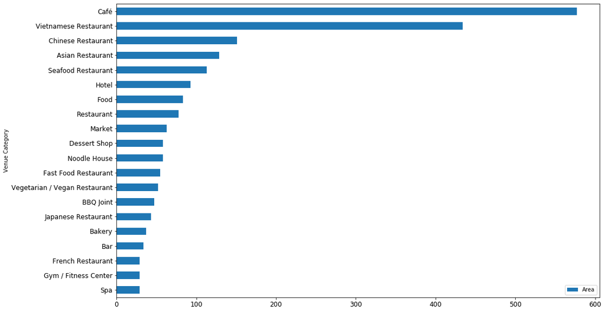

```python
import matplotlib.pyplot as plt
%matplotlib inline

hcmc_venues_counted.sort_values('Area', inplace=True)
hcmc_venues_counted.plot.barh(x='Venue Category', y='Area', fontsize = 12, figsize=(16, 10))
plt.savefig("hcm_top20_venues.png")
plt.show()
```

```python
# One-hot encoding
hcmc_venues_onehot = refined_hcmc_venues.copy()
hcmc_venues_onehot = pd.get_dummies(hcmc_venues_onehot[['Venue Category']], prefix="", prefix_sep="")

# Add Area, Ward, District columns back to dataframe
hcmc_venues_onehot['Area'] = refined_hcmc_venues['Area']

# Move Area column to the first column
fixed_columns = [hcmc_venues_onehot.columns[-1]] + list(hcmc_venues_onehot.columns[:-1])
hcmc_venues_onehot = hcmc_venues_onehot[fixed_columns]

hcmc_venues_grouped = hcmc_venues_onehot.groupby('Area').sum().reset_index()
print(hcmc_venues_grouped.shape)
hcmc_venues_grouped.head()
```

```
(279, 180)
```

|  | Area | Afghan Restaurant | American Restaurant | Arcade | Argentinian Restaurant | Art Gallery | Arts & Crafts Store | Arts & Entertainment | Asian Restaurant | Athletics & Sports | Australian Restaurant | BBQ Joint | Baby Store | Badminton Court | Bagel Shop | Bakery | Bar | Baseball Field | Basketball Stadium | Bathing Area | Beach | Beer Bar | Beer Garden | Boarding House | Boat or Ferry | Bookstore | Brazilian Restaurant | Breakfast Spot | Brewery | … |
| --- | --- | --- | --- | --- | --- | --- | --- | --- | --- | --- | --- | --- | --- | --- | --- | --- | --- | --- | --- | --- | --- | --- | --- | --- | --- | --- | --- | --- | --- | --- |
| 0 | Phường An Lạc, Quận Bình Tân | 0 | 0 | 0 | 0 | 0 | 0 | 0 | 0 | 0 | 0 | 0 | 0 | 0 | 0 | 0 | 0 | 0 | 0 | 0 | 0 | 0 | 0 | 0 | 0 | 0 | 0 | 0 | 0 | … |
| 1 | Phường 1, Quận 10 | 0 | 0 | 0 | 0 | 0 | 0 | 0 | 0 | 0 | 0 | 0 | 0 | 0 | 0 | 1 | 0 | 0 | 0 | 0 | 0 | 0 | 0 | 0 | 0 | 0 | 0 | 0 | 0 | … |
| 2 | Phường 1, Quận 11 | 0 | 0 | 0 | 0 | 0 | 0 | 0 | 0 | 0 | 0 | 0 | 0 | 0 | 0 | 0 | 0 | 0 | 0 | 0 | 0 | 0 | 0 | 0 | 0 | 0 | 0 | 0 | 0 | … |
| 3 | Phường 1, Quận 3 | 0 | 0 | 0 | 0 | 0 | 0 | 0 | 1 | 0 | 0 | 0 | 0 | 0 | 0 | 2 | 0 | 0 | 0 | 0 | 0 | 0 | 0 | 0 | 0 | 0 | 0 | 0 | 0 | … |
| 4 | Phường 1, Quận 4 | 0 | 1 | 0 | 0 | 0 | 0 | 0 | 2 | 1 | 0 | 0 | 0 | 0 | 0 | 0 | 0 | 0 | 0 | 0 | 0 | 0 | 0 | 0 | 0 | 0 | 0 | 0 | 0 | … |

```python
hcmc_venues_grouped.to_csv("HoChiMinhCity_Venues_Encoded.csv", index = False)
```

```python
# Remove columns whose number of zeros are more than 5%
hcmc_venues_grouped_trimmed = hcmc_venues_grouped.drop(columns = ["Area"])
hcmc_venues_grouped_trimmed = hcmc_venues_grouped_trimmed.loc[:, (hcmc_venues_grouped == 1).sum() > 0.05 * len(hcmc_venues_grouped)]

# Add Area column back to dataframe
hcmc_venues_grouped_trimmed['Area'] = hcmc_venues_grouped['Area']

# Move Area column to the first column
fixed_columns = [hcmc_venues_grouped_trimmed.columns[-1]]  + list(hcmc_venues_grouped_trimmed.columns[:-1])
hcmc_venues_grouped_trimmed = hcmc_venues_grouped_trimmed[fixed_columns]

hcmc_venues_grouped = hcmc_venues_grouped_trimmed
print(hcmc_venues_grouped.shape)
hcmc_venues_grouped.head()
```

```
(279, 32)
```

|  | Area | Asian Restaurant | BBQ Joint | Bakery | Bar | Bookstore | Breakfast Spot | Café | Chinese Restaurant | Convenience Store | Dessert Shop | Fast Food Restaurant | Food | Gym / Fitness Center | Hotel | Hotpot Restaurant | Ice Cream Shop | Japanese Restaurant | Korean Restaurant | Market | Multiplex | Noodle House | Pizza Place | Restaurant | Seafood Restaurant | Snack Place | Spa | Steakhouse | Supermarket | … |
| --- | --- | --- | --- | --- | --- | --- | --- | --- | --- | --- | --- | --- | --- | --- | --- | --- | --- | --- | --- | --- | --- | --- | --- | --- | --- | --- | --- | --- | --- | --- |
| 0 | Phường An Lạc, Quận Bình Tân | 0 | 0 | 0 | 0 | 0 | 0 | 0 | 0 | 0 | 0 | 0 | 0 | 0 | 0 | 0 | 0 | 0 | 0 | 0 | 0 | 0 | 0 | 0 | 0 | 0 | 0 | 0 | 0 | … |
| 1 | Phường 1, Quận 10 | 0 | 0 | 1 | 0 | 0 | 0 | 2 | 0 | 0 | 1 | 1 | 1 | 0 | 1 | 1 | 0 | 0 | 0 | 0 | 0 | 1 | 0 | 0 | 0 | 0 | 0 | 0 | 0 | … |
| 2 | Phường 1, Quận 11 | 0 | 0 | 0 | 0 | 0 | 0 | 0 | 0 | 0 | 1 | 0 | 0 | 0 | 0 | 0 | 0 | 0 | 0 | 0 | 0 | 0 | 0 | 1 | 0 | 0 | 0 | 0 | 0 | … |
| 3 | Phường 1, Quận 3 | 1 | 0 | 2 | 0 | 0 | 0 | 2 | 1 | 0 | 3 | 1 | 3 | 0 | 0 | 1 | 0 | 0 | 0 | 1 | 0 | 1 | 0 | 0 | 0 | 0 | 0 | 0 | 0 | … |
| 4 | Phường 1, Quận 4 | 2 | 0 | 0 | 0 | 0 | 0 | 1 | 0 | 0 | 0 | 0 | 0 | 0 | 0 | 0 | 0 | 0 | 0 | 0 | 0 | 0 | 0 | 0 | 1 | 0 | 0 | 0 | 0 | … |

```python
# Print each Area along with the top 5 most common venues
num_top_venues = 5
for area in hcmc_venues_grouped['Area']:
    print("----"+area+"----")
    temp = hcmc_venues_grouped[hcmc_venues_grouped['Area'] == area].T.reset_index()
    temp.columns = ['venue','freq']
    temp = temp.iloc[1:]
    temp['freq'] = temp['freq'].astype(float)
    temp = temp.round({'freq': 2})
    print(temp.sort_values('freq', ascending=False).reset_index(drop=True).head(num_top_venues))
    print('\n')
```

```
----Phường  An Lạc, Quận Bình Tân----
                           venue  freq
0          Vietnamese Restaurant   1.0
1            Japanese Restaurant   0.0
2  Vegetarian / Vegan Restaurant   0.0
3                Thai Restaurant   0.0
4                    Supermarket   0.0


----Phường 1, Quận 10----
                   venue  freq
0  Vietnamese Restaurant   2.0
1                   Café   2.0
2      Hotpot Restaurant   1.0
3                  Hotel   1.0
4                   Food   1.0


----Phường 1, Quận 11----
                           venue  freq
0          Vietnamese Restaurant   1.0
1                   Dessert Shop   1.0
2                     Restaurant   1.0
3            Japanese Restaurant   0.0
4  Vegetarian / Vegan Restaurant   0.0


----Phường 1, Quận 3----
                   venue  freq
0           Dessert Shop   3.0
1                   Food   3.0
2  Vietnamese Restaurant   2.0
3                 Bakery   2.0
4                   Café   2.0


----Phường 1, Quận 4----
                   venue  freq
0       Asian Restaurant   2.0
1                   Café   1.0
```

[output cut: 2454 more lines]

```
                           venue  freq
0                           Café   1.0
1               Asian Restaurant   0.0
2            Japanese Restaurant   0.0
3  Vegetarian / Vegan Restaurant   0.0
4                Thai Restaurant   0.0


----Xã Đông Thạnh, Huyện Hóc Môn----
                           venue  freq
0                            Bar   1.0
1               Asian Restaurant   0.0
2            Japanese Restaurant   0.0
3  Vegetarian / Vegan Restaurant   0.0
4                Thai Restaurant   0.0
```

```python
# Get Top20 most visited venues for each Area
num_top_venues = 20
indicators = ['st', 'nd', 'rd']

# Create columns according to number of top venues
columns = ['Area']
for ind in np.arange(num_top_venues):
    try:
        columns.append('{}{} Most Common Venue'.format(ind+1, indicators[ind]))
    except:
        columns.append('{}th Most Common Venue'.format(ind+1))

# create a new dataframe
hcmc_venues_sorted = pd.DataFrame(columns=columns)
hcmc_venues_sorted['Area'] = hcmc_venues_grouped['Area']

for ind in np.arange(hcmc_venues_grouped.shape[0]):
    hcmc_venues_sorted.iloc[ind, 1:] = return_most_common_venues(hcmc_venues_grouped.iloc[ind, :], num_top_venues)

hcmc_venues_sorted.head()
```

|  | Area | 1st Most Common Venue | 2nd Most Common Venue | 3rd Most Common Venue | 4th Most Common Venue | 5th Most Common Venue | 6th Most Common Venue | 7th Most Common Venue | 8th Most Common Venue | 9th Most Common Venue | 10th Most Common Venue | 11th Most Common Venue | 12th Most Common Venue | 13th Most Common Venue | 14th Most Common Venue | 15th Most Common Venue | 16th Most Common Venue | 17th Most Common Venue | 18th Most Common Venue | 19th Most Common Venue | 20th Most Common Venue |
| --- | --- | --- | --- | --- | --- | --- | --- | --- | --- | --- | --- | --- | --- | --- | --- | --- | --- | --- | --- | --- | --- |
| 0 | Phường An Lạc, Quận Bình Tân | Vietnamese Restaurant | Hotpot Restaurant | BBQ Joint | Bakery | Bar | Bookstore | Breakfast Spot | Café | Chinese Restaurant | Convenience Store | Dessert Shop | Fast Food Restaurant | Food | Gym / Fitness Center | Hotel | Ice Cream Shop | Vegetarian / Vegan Restaurant | Japanese Restaurant | Korean Restaurant | Market |
| 1 | Phường 1, Quận 10 | Vietnamese Restaurant | Café | Hotpot Restaurant | Bakery | Noodle House | Dessert Shop | Fast Food Restaurant | Food | Hotel | BBQ Joint | Bar | Bookstore | Breakfast Spot | Chinese Restaurant | Convenience Store | Gym / Fitness Center | Ice Cream Shop | Vegetarian / Vegan Restaurant | Japanese Restaurant | Korean Restaurant |
| 2 | Phường 1, Quận 11 | Vietnamese Restaurant | Restaurant | Dessert Shop | Hotpot Restaurant | BBQ Joint | Bakery | Bar | Bookstore | Breakfast Spot | Café | Chinese Restaurant | Convenience Store | Fast Food Restaurant | Food | Gym / Fitness Center | Hotel | Ice Cream Shop | Vegetarian / Vegan Restaurant | Japanese Restaurant | Korean Restaurant |
| 3 | Phường 1, Quận 3 | Dessert Shop | Food | Vietnamese Restaurant | Bakery | Café | Noodle House | Chinese Restaurant | Fast Food Restaurant | Hotpot Restaurant | Market | Asian Restaurant | Multiplex | Pizza Place | BBQ Joint | Thai Restaurant | Bar | Bookstore | Breakfast Spot | Supermarket | Steakhouse |
| 4 | Phường 1, Quận 4 | Asian Restaurant | Seafood Restaurant | Café | Vietnamese Restaurant | Steakhouse | Gym / Fitness Center | BBQ Joint | Bakery | Bar | Bookstore | Breakfast Spot | Thai Restaurant | Chinese Restaurant | Convenience Store | Dessert Shop | Fast Food Restaurant | Food | Hotel | Spa | Hotpot Restaurant |

```python
# Normalize data
hcmc_venues_normalized = hcmc_venues_grouped.copy()
hcmc_venues_normalized = hcmc_venues_normalized.drop(columns = ["Area"])
temp_df = preprocessing.StandardScaler().fit(hcmc_venues_normalized).transform(hcmc_venues_normalized)
hcmc_venues_normalized = pd.DataFrame(temp_df, columns=hcmc_venues_normalized.columns, index=hcmc_venues_normalized.index)

# Add Area column back to dataframe
hcmc_venues_normalized['Area'] = hcmc_venues_grouped['Area']

# Move Area column to the first column
fixed_columns = [hcmc_venues_normalized.columns[-1]]  + list(hcmc_venues_normalized.columns[:-1])
hcmc_venues_normalized = hcmc_venues_normalized[fixed_columns]

hcmc_venues_normalized.head()
```

|  | Area | Asian Restaurant | BBQ Joint | Bakery | Bar | Bookstore | Breakfast Spot | Café | Chinese Restaurant | Convenience Store | Dessert Shop | Fast Food Restaurant | Food | Gym / Fitness Center | Hotel | Hotpot Restaurant | Ice Cream Shop | Japanese Restaurant | Korean Restaurant | Market | Multiplex | Noodle House | Pizza Place | Restaurant | Seafood Restaurant | Snack Place | Spa | Steakhouse | Supermarket | … |
| --- | --- | --- | --- | --- | --- | --- | --- | --- | --- | --- | --- | --- | --- | --- | --- | --- | --- | --- | --- | --- | --- | --- | --- | --- | --- | --- | --- | --- | --- | --- |
| 0 | Phường An Lạc, Quận Bình Tân | -0.567265 | -0.386207 | -0.268440 | -0.210109 | -0.260967 | -0.282138 | -0.692587 | -0.360375 | -0.229848 | -0.374560 | -0.398844 | -0.481939 | -0.306986 | -0.264832 | -0.246651 | -0.260967 | -0.280263 | -0.248282 | -0.491977 | -0.229848 | -0.403811 | -0.300157 | -0.461935 | -0.439227 | -0.271851 | -0.217047 | -0.238366 | -0.271653 | … |
| 1 | Phường 1, Quận 10 | -0.567265 | -0.386207 | 1.755745 | -0.210109 | -0.260967 | -0.282138 | -0.022806 | -0.360375 | -0.229848 | 1.427203 | 1.624383 | 1.138074 | -0.306986 | 0.529663 | 4.054319 | -0.260967 | -0.280263 | -0.248282 | -0.491977 | -0.229848 | 1.538660 | -0.300157 | -0.461935 | -0.439227 | -0.271851 | -0.217047 | -0.238366 | -0.271653 | … |
| 2 | Phường 1, Quận 11 | -0.567265 | -0.386207 | -0.268440 | -0.210109 | -0.260967 | -0.282138 | -0.692587 | -0.360375 | -0.229848 | 1.427203 | -0.398844 | -0.481939 | -0.306986 | -0.264832 | -0.246651 | -0.260967 | -0.280263 | -0.248282 | -0.491977 | -0.229848 | -0.403811 | -0.300157 | 1.190371 | -0.439227 | -0.271851 | -0.217047 | -0.238366 | -0.271653 | … |
| 3 | Phường 1, Quận 3 | 0.659610 | -0.386207 | 3.779930 | -0.210109 | -0.260967 | -0.282138 | -0.022806 | 0.305483 | -0.229848 | 5.030730 | 1.624383 | 4.378101 | -0.306986 | -0.264832 | 4.054319 | -0.260967 | -0.280263 | -0.248282 | 1.686779 | -0.229848 | 1.538660 | -0.300157 | -0.461935 | -0.439227 | -0.271851 | -0.217047 | -0.238366 | -0.271653 | … |
| 4 | Phường 1, Quận 4 | 1.886484 | -0.386207 | -0.268440 | -0.210109 | -0.260967 | -0.282138 | -0.357696 | -0.360375 | -0.229848 | -0.374560 | -0.398844 | -0.481939 | -0.306986 | -0.264832 | -0.246651 | -0.260967 | -0.280263 | -0.248282 | -0.491977 | -0.229848 | -0.403811 | -0.300157 | -0.461935 | 0.645236 | -0.271851 | -0.217047 | -0.238366 | -0.271653 | … |

## Methodolody

K-mean clustering, an unsupervised machine learning algorithm is used in this project to cluster the venues based on the list of locations for different types of visiting purposes such as Vietnamese restaurants, Chinese restaurants, bars, sports, café, foods and beverages, etc. The resulting output would give a better understanding of similarities and dissimilarities between the chosen areas (or neighborhoods) to retrieve more insights and to conclude which ares wins over others.

Silhoutte score is applied to determine the optimal number of clusters for K-mean algorithm. Labels obtained from the clustering result, with the optimum value of number of clusters, is then assigned to each area by the help of Pandas merge functions.

Map with circled markers representing corresponding area locations is then shown to visualize the resulting clusters. Each cluster is then extracted from the clustering dataframe and a horizontal bar-chart is shown to get a closer insight to the most common venues of each cluster, hopefully yielding some useful information.

##### 1. Cluster Areas

###### Silhouette Analysis method is used to find the optimal cluster number for the Kmean algorithm

```python
hcmc_venues_grouped_clustering = hcmc_venues_normalized.copy()
hcmc_venues_grouped_clustering = hcmc_venues_grouped_clustering.drop('Area', 1)
from sklearn.cluster import KMeans
from sklearn.metrics import silhouette_samples, silhouette_score
range_n_clusters = range(2, 20)
scores = []
for n_clusters in range_n_clusters:
    clusterer = KMeans(n_clusters=n_clusters, random_state=0).fit(hcmc_venues_grouped_clustering)
    preds = clusterer.fit_predict(hcmc_venues_grouped_clustering)
    centers = clusterer.cluster_centers_

    score = silhouette_score(hcmc_venues_grouped_clustering, preds, metric='euclidean')
    print ("For n_clusters = {}, silhouette score is {})".format(n_clusters, score))
    scores.append(score)

#scores = abs(np.array(scores))
print("The best core {} obtained at K = {}".format(min(scores), np.argmin(scores) + 2))
```

[output not shown]

###### Run k-means to cluster the Areas

```python
from sklearn.cluster import KMeans
kclusters = np.argmin(scores) + 2

hcmc_venues_grouped_clustering = hcmc_venues_normalized.drop('Area', 1)

# Run k-means clustering
kmeans = KMeans(n_clusters=kclusters, random_state=0).fit(hcmc_venues_grouped_clustering)

# Check cluster labels generated for each row in the dataframe
kmeans.labels_
print(len(kmeans.labels_))
print(hcmc_venues_grouped.shape)
```

```
279
(279, 32)
```

###### Create a new dataframe that includes the cluster as well as the top 20 venues for each Area.

```python
hcmc_venues_sorted.head()
```

|  | Area | 1st Most Common Venue | 2nd Most Common Venue | 3rd Most Common Venue | 4th Most Common Venue | 5th Most Common Venue | 6th Most Common Venue | 7th Most Common Venue | 8th Most Common Venue | 9th Most Common Venue | 10th Most Common Venue | 11th Most Common Venue | 12th Most Common Venue | 13th Most Common Venue | 14th Most Common Venue | 15th Most Common Venue | 16th Most Common Venue | 17th Most Common Venue | 18th Most Common Venue | 19th Most Common Venue | 20th Most Common Venue |
| --- | --- | --- | --- | --- | --- | --- | --- | --- | --- | --- | --- | --- | --- | --- | --- | --- | --- | --- | --- | --- | --- |
| 0 | Phường An Lạc, Quận Bình Tân | Vietnamese Restaurant | Hotpot Restaurant | BBQ Joint | Bakery | Bar | Bookstore | Breakfast Spot | Café | Chinese Restaurant | Convenience Store | Dessert Shop | Fast Food Restaurant | Food | Gym / Fitness Center | Hotel | Ice Cream Shop | Vegetarian / Vegan Restaurant | Japanese Restaurant | Korean Restaurant | Market |
| 1 | Phường 1, Quận 10 | Vietnamese Restaurant | Café | Hotpot Restaurant | Bakery | Noodle House | Dessert Shop | Fast Food Restaurant | Food | Hotel | BBQ Joint | Bar | Bookstore | Breakfast Spot | Chinese Restaurant | Convenience Store | Gym / Fitness Center | Ice Cream Shop | Vegetarian / Vegan Restaurant | Japanese Restaurant | Korean Restaurant |
| 2 | Phường 1, Quận 11 | Vietnamese Restaurant | Restaurant | Dessert Shop | Hotpot Restaurant | BBQ Joint | Bakery | Bar | Bookstore | Breakfast Spot | Café | Chinese Restaurant | Convenience Store | Fast Food Restaurant | Food | Gym / Fitness Center | Hotel | Ice Cream Shop | Vegetarian / Vegan Restaurant | Japanese Restaurant | Korean Restaurant |
| 3 | Phường 1, Quận 3 | Dessert Shop | Food | Vietnamese Restaurant | Bakery | Café | Noodle House | Chinese Restaurant | Fast Food Restaurant | Hotpot Restaurant | Market | Asian Restaurant | Multiplex | Pizza Place | BBQ Joint | Thai Restaurant | Bar | Bookstore | Breakfast Spot | Supermarket | Steakhouse |
| 4 | Phường 1, Quận 4 | Asian Restaurant | Seafood Restaurant | Café | Vietnamese Restaurant | Steakhouse | Gym / Fitness Center | BBQ Joint | Bakery | Bar | Bookstore | Breakfast Spot | Thai Restaurant | Chinese Restaurant | Convenience Store | Dessert Shop | Fast Food Restaurant | Food | Hotel | Spa | Hotpot Restaurant |

```python
hcmc_dw_df.head()
```

|  | Ward | District | Area | Latitude | Longitude |
| --- | --- | --- | --- | --- | --- |
| 0 | Phường Tân Định | Quận 1 | Phường Tân Định, Quận 1 | 10.79266 | 106.69129 |
| 1 | Phường Đa Kao | Quận 1 | Phường Đa Kao, Quận 1 | 10.78839 | 106.69759 |
| 2 | Phường Bến Nghé | Quận 1 | Phường Bến Nghé, Quận 1 | 10.78133 | 106.70537 |
| 3 | Phường Bến Thành | Quận 1 | Phường Bến Thành, Quận 1 | 10.77323 | 106.69899 |
| 4 | Phường Nguyễn Thái Bình | Quận 1 | Phường Nguyễn Thái Bình, Quận 1 | 10.76790 | 106.70050 |

```python
# Add clustering labels
hcmc_grouped_clustering = hcmc_venues_grouped.drop('Area', 1)
hcmc_venues_sorted.insert(0, 'Cluster Labels', kmeans.labels_)

hcmc_venues_merged = hcmc_dw_df.copy()

# Merge hcmc_venues_grouped with hcmc_dw_df to add latitude/longitude for each Area
hcmc_venues_merged = hcmc_venues_merged.join(hcmc_venues_sorted.set_index('Area'), on='Area')

hcmc_venues_merged = hcmc_venues_merged[hcmc_venues_merged['Cluster Labels'].notnull()]
hcmc_venues_merged.head()
```

|  | Ward | District | Area | Latitude | Longitude | Cluster Labels | 1st Most Common Venue | 2nd Most Common Venue | 3rd Most Common Venue | 4th Most Common Venue | 5th Most Common Venue | 6th Most Common Venue | 7th Most Common Venue | 8th Most Common Venue | 9th Most Common Venue | 10th Most Common Venue | 11th Most Common Venue | 12th Most Common Venue | 13th Most Common Venue | 14th Most Common Venue | 15th Most Common Venue | 16th Most Common Venue | 17th Most Common Venue | 18th Most Common Venue | 19th Most Common Venue | 20th Most Common Venue |
| --- | --- | --- | --- | --- | --- | --- | --- | --- | --- | --- | --- | --- | --- | --- | --- | --- | --- | --- | --- | --- | --- | --- | --- | --- | --- | --- |
| 0 | Phường Tân Định | Quận 1 | Phường Tân Định, Quận 1 | 10.79266 | 106.69129 | 7.0 | Vietnamese Restaurant | Café | Vegetarian / Vegan Restaurant | Breakfast Spot | Asian Restaurant | Spa | Food | Bar | Market | Snack Place | BBQ Joint | Bakery | Bookstore | Thai Restaurant | Supermarket | Chinese Restaurant | Convenience Store | Dessert Shop | Fast Food Restaurant | Gym / Fitness Center |
| 1 | Phường Đa Kao | Quận 1 | Phường Đa Kao, Quận 1 | 10.78839 | 106.69759 | 12.0 | Vietnamese Restaurant | Café | Japanese Restaurant | Vegetarian / Vegan Restaurant | BBQ Joint | Bakery | Breakfast Spot | Dessert Shop | Asian Restaurant | Restaurant | Fast Food Restaurant | Gym / Fitness Center | Bar | Steakhouse | Spa | Chinese Restaurant | Noodle House | Ice Cream Shop | Hotel | Seafood Restaurant |
| 2 | Phường Bến Nghé | Quận 1 | Phường Bến Nghé, Quận 1 | 10.78133 | 106.70537 | 8.0 | Bar | Hotel | Café | Spa | Vietnamese Restaurant | Restaurant | Korean Restaurant | BBQ Joint | Convenience Store | Dessert Shop | Gym / Fitness Center | Asian Restaurant | Thai Restaurant | Noodle House | Pizza Place | Steakhouse | Market | Chinese Restaurant | Bakery | Supermarket |
| 3 | Phường Bến Thành | Quận 1 | Phường Bến Thành, Quận 1 | 10.77323 | 106.69899 | 2.0 | Vietnamese Restaurant | Café | Hotel | Spa | Asian Restaurant | Restaurant | Bar | Fast Food Restaurant | BBQ Joint | Pizza Place | Dessert Shop | Japanese Restaurant | Food | Steakhouse | Supermarket | Bakery | Thai Restaurant | Ice Cream Shop | Multiplex | Noodle House |
| 4 | Phường Nguyễn Thái Bình | Quận 1 | Phường Nguyễn Thái Bình, Quận 1 | 10.76790 | 106.70050 | 14.0 | Vietnamese Restaurant | Restaurant | Bar | BBQ Joint | Café | Fast Food Restaurant | Hotel | Ice Cream Shop | Food | Dessert Shop | Market | Japanese Restaurant | Spa | Thai Restaurant | Bakery | Supermarket | Bookstore | Breakfast Spot | Steakhouse | Chinese Restaurant |

##### 2. Visualize the resulting clusters

```python
import matplotlib.cm as cm
import matplotlib.colors as colors
```

```python
_str = "Thành Phố Hồ Chí Minh"
geocode_result = here_maps.free_form(_str).as_dict()
hcmc_latitude = geocode_result["Response"]["View"][0]["Result"][0]["Location"]["NavigationPosition"][0]["Latitude"]
hcmc_longitude =  geocode_result["Response"]["View"][0]["Result"][0]["Location"]["NavigationPosition"][0]["Longitude"]

#hcmc_map = folium.Map(location=[hcmc_latitude, hcmc_longitude], zoom_start=12)
#hcmc_map
```

```python
# create map
map_clusters = folium.Map(location=[hcmc_latitude, hcmc_longitude], zoom_start=12)

# set color scheme for the clusters
x = np.arange(kclusters)
ys = [i + x + (i*x)**2 for i in range(kclusters)]
colors_array = cm.rainbow(np.linspace(0, 1, len(ys)))
rainbow = [colors.rgb2hex(i) for i in colors_array]
print(rainbow)

# add markers to the map
markers_colors = []
for lat, lon, poi, cluster in zip(hcmc_venues_merged['Latitude'], hcmc_venues_merged['Longitude'], hcmc_venues_merged['Area'], hcmc_venues_merged['Cluster Labels']):
    label = folium.Popup(str(poi) + ' Cluster ' + str(cluster), parse_html=True)
    folium.CircleMarker(
        [lat, lon],
        radius=5,
        popup=label,
        color= rainbow[int(cluster)],
        fill=True,
        fill_color=rainbow[int(cluster)],
        fill_opacity=0.7).add_to(map_clusters)

map_clusters.save('hcmc_map.html')
map_clusters
```

```
['#8000ff', '#642cfe', '#4856fb', '#2c7ef7', '#10a2f0', '#0fc4e7', '#2adddd', '#46efd1', '#62fbc4', '#80ffb4', '#9cfba4', '#b9ef92', '#d4dd80', '#f0c46c', '#ffa256', '#ff7e41', '#ff562c', '#ff2c16', '#ff0000']
```

[interactive chart not shown]

## Results

##### Examine Clusters

```python
def plot_top_most_common_venues(data, top_number):
    extracted_data = data.copy()
    extracted_data = extracted_data.groupby('1st Most Common Venue').count()
    extracted_data = extracted_data.sort_values(by=['Area'], ascending=False).head(top_number)
    extracted_data = extracted_data.reset_index()
    extracted_data = extracted_data[['1st Most Common Venue', 'Area']]

    import matplotlib.pyplot as plt
    %matplotlib inline

    extracted_data.sort_values('Area', inplace=True)
    extracted_data.plot.barh(x='1st Most Common Venue', y='Area', fontsize = 12, figsize=(16, 10))
    #plt.savefig("hcm_venues.png")
    plt.show()
```

```python
def show_cluster_inf(data, cluster_index, top_number):
    cluster_df = hcmc_venues_merged.loc[hcmc_venues_merged['Cluster Labels'] == cluster_index, hcmc_venues_merged.columns[[2] + list(range(5, hcmc_venues_merged.shape[1]))], ]
    print("Number of Area in the cluster: {}".format(len(cluster_df)))
    plot_top_most_common_venues(cluster_df, top_number)

    return cluster_df
```

###### Cluster 1

```
Number of Area in the cluster: 17
```

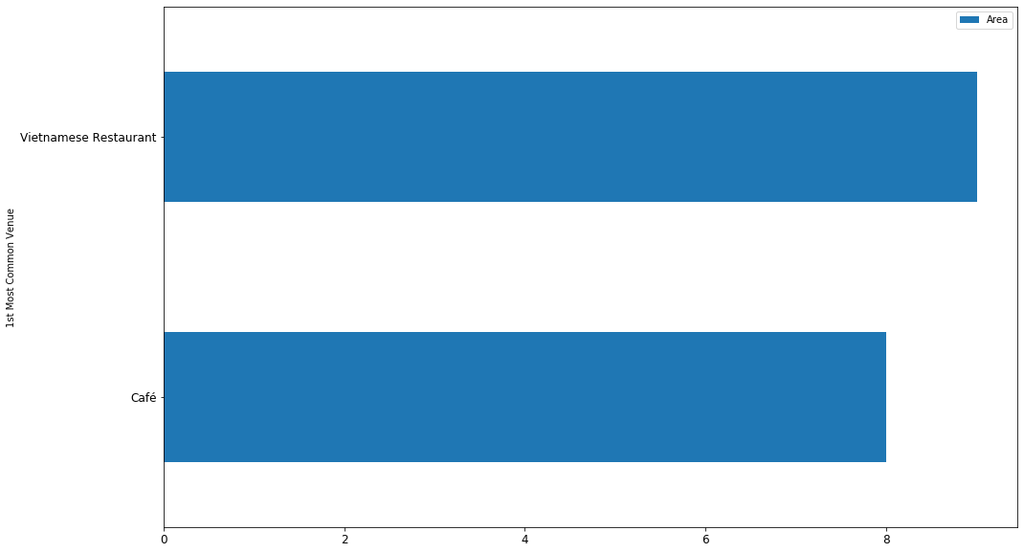

```python
cluster_1 = show_cluster_inf(hcmc_venues_merged, 0, 5)
```

```python
cluster_1
```

|  | Area | Cluster Labels | 1st Most Common Venue | 2nd Most Common Venue | 3rd Most Common Venue | 4th Most Common Venue | 5th Most Common Venue | 6th Most Common Venue | 7th Most Common Venue | 8th Most Common Venue | 9th Most Common Venue | 10th Most Common Venue | 11th Most Common Venue | 12th Most Common Venue | 13th Most Common Venue | 14th Most Common Venue | 15th Most Common Venue | 16th Most Common Venue | 17th Most Common Venue | 18th Most Common Venue | 19th Most Common Venue | 20th Most Common Venue |
| --- | --- | --- | --- | --- | --- | --- | --- | --- | --- | --- | --- | --- | --- | --- | --- | --- | --- | --- | --- | --- | --- | --- |
| 7 | Phường Cô Giang, Quận 1 | 0.0 | Vietnamese Restaurant | Hotel | Steakhouse | Spa | Vegetarian / Vegan Restaurant | Seafood Restaurant | Restaurant | Food | Japanese Restaurant | Chinese Restaurant | Dessert Shop | Convenience Store | Bookstore | Café | Breakfast Spot | Bar | Bakery | BBQ Joint | Fast Food Restaurant | Ice Cream Shop |
| 86 | Phường 1, Quận Tân Bình | 0.0 | Café | Vietnamese Restaurant | Hotel | Seafood Restaurant | Gym / Fitness Center | Noodle House | Ice Cream Shop | Snack Place | Restaurant | BBQ Joint | Bakery | Bar | Bookstore | Breakfast Spot | Thai Restaurant | Chinese Restaurant | Convenience Store | Dessert Shop | Fast Food Restaurant | Food |
| 94 | Phường 9, Quận Tân Bình | 0.0 | Vietnamese Restaurant | Steakhouse | Café | Fast Food Restaurant | Hotpot Restaurant | BBQ Joint | Bakery | Bar | Bookstore | Breakfast Spot | Chinese Restaurant | Convenience Store | Dessert Shop | Food | Gym / Fitness Center | Hotel | Ice Cream Shop | Vegetarian / Vegan Restaurant | Japanese Restaurant | Korean Restaurant |
| 97 | Phường Tân Sơn Nhì, Quận Tân Phú | 0.0 | Vietnamese Restaurant | Steakhouse | Café | Asian Restaurant | Supermarket | Gym / Fitness Center | BBQ Joint | Bakery | Bar | Bookstore | Breakfast Spot | Thai Restaurant | Chinese Restaurant | Convenience Store | Dessert Shop | Fast Food Restaurant | Food | Hotel | Spa | Hotpot Restaurant |
| 113 | Phường 1, Quận Phú Nhuận | 0.0 | Café | Vietnamese Restaurant | Restaurant | BBQ Joint | Bookstore | Gym / Fitness Center | Pizza Place | Asian Restaurant | Seafood Restaurant | Fast Food Restaurant | Thai Restaurant | Bakery | Bar | Supermarket | Breakfast Spot | Steakhouse | Chinese Restaurant | Convenience Store | Dessert Shop | Food |
| 116 | Phường 15, Quận Phú Nhuận | 0.0 | Café | Vietnamese Restaurant | Hotel | BBQ Joint | Bookstore | Chinese Restaurant | Asian Restaurant | Spa | Seafood Restaurant | Restaurant | Thai Restaurant | Bakery | Bar | Supermarket | Breakfast Spot | Steakhouse | Convenience Store | Dessert Shop | Fast Food Restaurant | Food |
| 119 | Phường 17, Quận Phú Nhuận | 0.0 | Vietnamese Restaurant | Café | Vegetarian / Vegan Restaurant | Seafood Restaurant | Bakery | Bookstore | Ice Cream Shop | Spa | Snack Place | Fast Food Restaurant | BBQ Joint | Thai Restaurant | Bar | Supermarket | Breakfast Spot | Steakhouse | Chinese Restaurant | Convenience Store | Dessert Shop | Food |
| 120 | Phường 14, Quận Phú Nhuận | 0.0 | Vietnamese Restaurant | Café | Steakhouse | Gym / Fitness Center | Hotpot Restaurant | BBQ Joint | Bakery | Bar | Bookstore | Breakfast Spot | Chinese Restaurant | Convenience Store | Dessert Shop | Fast Food Restaurant | Food | Hotel | Ice Cream Shop | Vegetarian / Vegan Restaurant | Japanese Restaurant | Korean Restaurant |
| 121 | Phường 12, Quận Phú Nhuận | 0.0 | Café | Vietnamese Restaurant | Restaurant | Asian Restaurant | Hotel | BBQ Joint | Seafood Restaurant | Chinese Restaurant | Spa | Food | Bakery | Bar | Bookstore | Breakfast Spot | Thai Restaurant | Convenience Store | Dessert Shop | Fast Food Restaurant | Steakhouse | Gym / Fitness Center |
| 122 | Phường 13, Quận Phú Nhuận | 0.0 | Vietnamese Restaurant | Café | Bakery | Steakhouse | Hotpot Restaurant | BBQ Joint | Bar | Bookstore | Breakfast Spot | Chinese Restaurant | Convenience Store | Dessert Shop | Fast Food Restaurant | Food | Gym / Fitness Center | Hotel | Ice Cream Shop | Vegetarian / Vegan Restaurant | Japanese Restaurant | Korean Restaurant |
| 136 | Phường 14, Quận 3 | 0.0 | Café | Vietnamese Restaurant | Spa | Vegetarian / Vegan Restaurant | Seafood Restaurant | Restaurant | Bakery | BBQ Joint | Bookstore | Bar | Gym / Fitness Center | Breakfast Spot | Chinese Restaurant | Convenience Store | Dessert Shop | Fast Food Restaurant | Food | Ice Cream Shop | Hotel | Hotpot Restaurant |
| 137 | Phường 12, Quận 3 | 0.0 | Café | Vietnamese Restaurant | Restaurant | Steakhouse | Hotel | Pizza Place | Fast Food Restaurant | Bakery | Bar | Bookstore | Breakfast Spot | BBQ Joint | Chinese Restaurant | Convenience Store | Dessert Shop | Food | Gym / Fitness Center | Ice Cream Shop | Hotpot Restaurant | Vegetarian / Vegan Restaurant |
| 143 | Phường 4, Quận 3 | 0.0 | Café | Vietnamese Restaurant | Noodle House | Bakery | Chinese Restaurant | Vegetarian / Vegan Restaurant | Japanese Restaurant | Market | Ice Cream Shop | Asian Restaurant | Steakhouse | Restaurant | BBQ Joint | Thai Restaurant | Bar | Bookstore | Breakfast Spot | Supermarket | Convenience Store | Dessert Shop |
| 149 | Phường 13, Quận 10 | 0.0 | Vietnamese Restaurant | Café | Supermarket | Steakhouse | Fast Food Restaurant | Seafood Restaurant | Hotel | Chinese Restaurant | Food | Dessert Shop | Convenience Store | Bookstore | Breakfast Spot | Bar | Bakery | BBQ Joint | Gym / Fitness Center | Ice Cream Shop | Hotpot Restaurant | Vegetarian / Vegan Restaurant |
| 151 | Phường 12, Quận 10 | 0.0 | Café | Vietnamese Restaurant | Vegetarian / Vegan Restaurant | Steakhouse | Spa | Korean Restaurant | Gym / Fitness Center | Convenience Store | Fast Food Restaurant | Dessert Shop | Breakfast Spot | Chinese Restaurant | Bookstore | Bar | Bakery | BBQ Joint | Food | Ice Cream Shop | Hotel | Hotpot Restaurant |
| 209 | Phường 14, Quận 6 | 0.0 | Vietnamese Restaurant | BBQ Joint | Bakery | Steakhouse | Café | Market | Hotel | Bar | Bookstore | Breakfast Spot | Chinese Restaurant | Convenience Store | Dessert Shop | Fast Food Restaurant | Food | Gym / Fitness Center | Ice Cream Shop | Hotpot Restaurant | Vegetarian / Vegan Restaurant | Japanese Restaurant |
| 253 | Phường Bình Thuận, Quận 7 | 0.0 | Vietnamese Restaurant | Steakhouse | Café | Asian Restaurant | Supermarket | Gym / Fitness Center | BBQ Joint | Bakery | Bar | Bookstore | Breakfast Spot | Thai Restaurant | Chinese Restaurant | Convenience Store | Dessert Shop | Fast Food Restaurant | Food | Hotel | Spa | Hotpot Restaurant |

###### Cluster 2

```
Number of Area in the cluster: 2
```

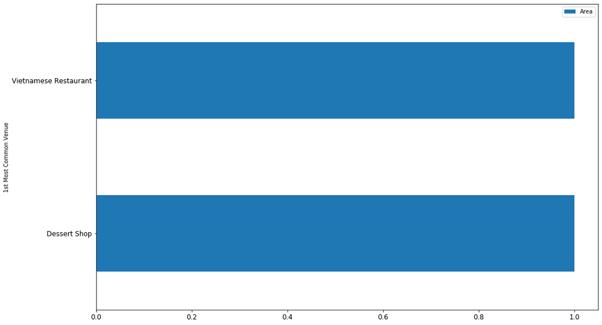

```python
cluster_2 = show_cluster_inf(hcmc_venues_merged, 1, 5)
```

```python
cluster_2
```

|  | Area | Cluster Labels | 1st Most Common Venue | 2nd Most Common Venue | 3rd Most Common Venue | 4th Most Common Venue | 5th Most Common Venue | 6th Most Common Venue | 7th Most Common Venue | 8th Most Common Venue | 9th Most Common Venue | 10th Most Common Venue | 11th Most Common Venue | 12th Most Common Venue | 13th Most Common Venue | 14th Most Common Venue | 15th Most Common Venue | 16th Most Common Venue | 17th Most Common Venue | 18th Most Common Venue | 19th Most Common Venue | 20th Most Common Venue |
| --- | --- | --- | --- | --- | --- | --- | --- | --- | --- | --- | --- | --- | --- | --- | --- | --- | --- | --- | --- | --- | --- | --- |
| 145 | Phường 3, Quận 3 | 1.0 | Vietnamese Restaurant | Café | Dessert Shop | Bakery | Asian Restaurant | Hotel | Food | Spa | Market | Japanese Restaurant | Chinese Restaurant | Hotpot Restaurant | Snack Place | Convenience Store | Steakhouse | BBQ Joint | Thai Restaurant | Bar | Bookstore | Breakfast Spot |
| 147 | Phường 1, Quận 3 | 1.0 | Dessert Shop | Food | Vietnamese Restaurant | Bakery | Café | Noodle House | Chinese Restaurant | Fast Food Restaurant | Hotpot Restaurant | Market | Asian Restaurant | Multiplex | Pizza Place | BBQ Joint | Thai Restaurant | Bar | Bookstore | Breakfast Spot | Supermarket | Steakhouse |

###### Cluster 3

```
Number of Area in the cluster: 2
```

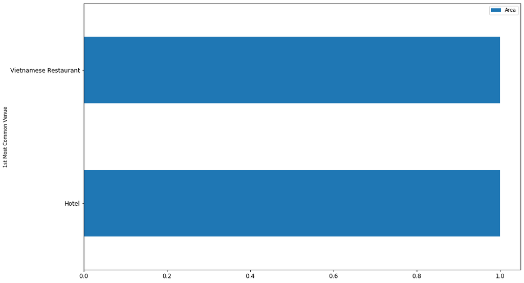

```python
cluster_3 = show_cluster_inf(hcmc_venues_merged, 2, 5)
```

```python
cluster_3
```

|  | Area | Cluster Labels | 1st Most Common Venue | 2nd Most Common Venue | 3rd Most Common Venue | 4th Most Common Venue | 5th Most Common Venue | 6th Most Common Venue | 7th Most Common Venue | 8th Most Common Venue | 9th Most Common Venue | 10th Most Common Venue | 11th Most Common Venue | 12th Most Common Venue | 13th Most Common Venue | 14th Most Common Venue | 15th Most Common Venue | 16th Most Common Venue | 17th Most Common Venue | 18th Most Common Venue | 19th Most Common Venue | 20th Most Common Venue |
| --- | --- | --- | --- | --- | --- | --- | --- | --- | --- | --- | --- | --- | --- | --- | --- | --- | --- | --- | --- | --- | --- | --- |
| 3 | Phường Bến Thành, Quận 1 | 2.0 | Vietnamese Restaurant | Café | Hotel | Spa | Asian Restaurant | Restaurant | Bar | Fast Food Restaurant | BBQ Joint | Pizza Place | Dessert Shop | Japanese Restaurant | Food | Steakhouse | Supermarket | Bakery | Thai Restaurant | Ice Cream Shop | Multiplex | Noodle House |
| 5 | Phường Phạm Ngũ Lão, Quận 1 | 2.0 | Hotel | Vietnamese Restaurant | Café | Japanese Restaurant | Bar | Spa | Restaurant | Food | Vegetarian / Vegan Restaurant | Asian Restaurant | Seafood Restaurant | Fast Food Restaurant | BBQ Joint | Bakery | Pizza Place | Thai Restaurant | Chinese Restaurant | Convenience Store | Bookstore | Breakfast Spot |

###### Cluster 4

```
Number of Area in the cluster: 3
```

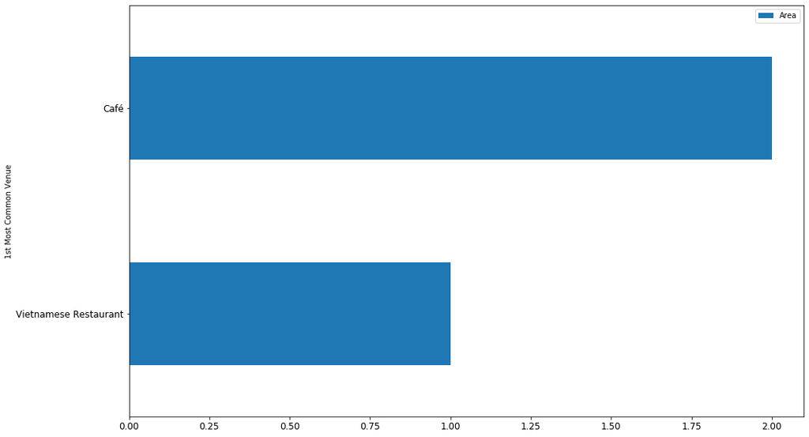

```python
cluster_4 = show_cluster_inf(hcmc_venues_merged, 3, 5)
```

```python
cluster_4
```

|  | Area | Cluster Labels | 1st Most Common Venue | 2nd Most Common Venue | 3rd Most Common Venue | 4th Most Common Venue | 5th Most Common Venue | 6th Most Common Venue | 7th Most Common Venue | 8th Most Common Venue | 9th Most Common Venue | 10th Most Common Venue | 11th Most Common Venue | 12th Most Common Venue | 13th Most Common Venue | 14th Most Common Venue | 15th Most Common Venue | 16th Most Common Venue | 17th Most Common Venue | 18th Most Common Venue | 19th Most Common Venue | 20th Most Common Venue |
| --- | --- | --- | --- | --- | --- | --- | --- | --- | --- | --- | --- | --- | --- | --- | --- | --- | --- | --- | --- | --- | --- | --- |
| 134 | Phường 8, Quận 3 | 3.0 | Café | Vietnamese Restaurant | Asian Restaurant | Vegetarian / Vegan Restaurant | Bar | Seafood Restaurant | Noodle House | Hotel | Bakery | Bookstore | Dessert Shop | Food | Ice Cream Shop | Market | Snack Place | Korean Restaurant | Chinese Restaurant | BBQ Joint | Spa | Restaurant |
| 140 | Phường 6, Quận 3 | 3.0 | Café | Vietnamese Restaurant | Vegetarian / Vegan Restaurant | Asian Restaurant | Hotel | Bakery | Chinese Restaurant | Snack Place | BBQ Joint | Pizza Place | Breakfast Spot | Hotpot Restaurant | Food | Bar | Bookstore | Thai Restaurant | Convenience Store | Dessert Shop | Fast Food Restaurant | Steakhouse |
| 144 | Phường 5, Quận 3 | 3.0 | Vietnamese Restaurant | Café | Snack Place | Bakery | Hotel | Vegetarian / Vegan Restaurant | Asian Restaurant | Seafood Restaurant | Gym / Fitness Center | BBQ Joint | Supermarket | Chinese Restaurant | Food | Pizza Place | Market | Noodle House | Korean Restaurant | Multiplex | Thai Restaurant | Bar |

###### Cluster 5

```
Number of Area in the cluster: 11
```

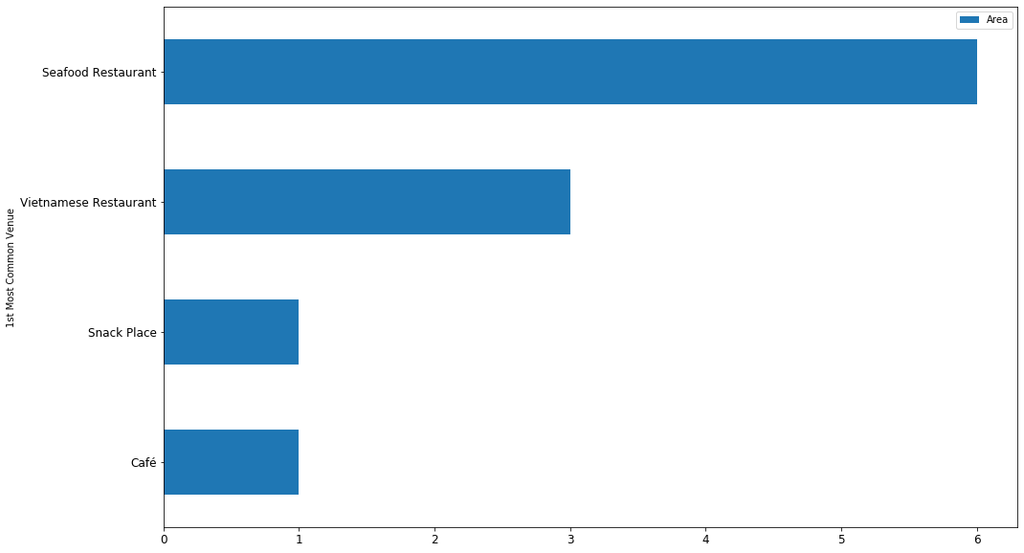

```python
cluster_5 = show_cluster_inf(hcmc_venues_merged, 4, 5)
```

```python
cluster_5
```

|  | Area | Cluster Labels | 1st Most Common Venue | 2nd Most Common Venue | 3rd Most Common Venue | 4th Most Common Venue | 5th Most Common Venue | 6th Most Common Venue | 7th Most Common Venue | 8th Most Common Venue | 9th Most Common Venue | 10th Most Common Venue | 11th Most Common Venue | 12th Most Common Venue | 13th Most Common Venue | 14th Most Common Venue | 15th Most Common Venue | 16th Most Common Venue | 17th Most Common Venue | 18th Most Common Venue | 19th Most Common Venue | 20th Most Common Venue |
| --- | --- | --- | --- | --- | --- | --- | --- | --- | --- | --- | --- | --- | --- | --- | --- | --- | --- | --- | --- | --- | --- | --- |
| 112 | Phường 3, Quận Phú Nhuận | 4.0 | Café | Vietnamese Restaurant | Pizza Place | BBQ Joint | Food | Gym / Fitness Center | Asian Restaurant | Snack Place | Seafood Restaurant | Fast Food Restaurant | Thai Restaurant | Bakery | Bar | Bookstore | Breakfast Spot | Supermarket | Chinese Restaurant | Convenience Store | Dessert Shop | Steakhouse |
| 142 | Phường 10, Quận 3 | 4.0 | Seafood Restaurant | Vietnamese Restaurant | Café | Fast Food Restaurant | Chinese Restaurant | Gym / Fitness Center | Restaurant | Snack Place | BBQ Joint | Thai Restaurant | Bar | Bookstore | Breakfast Spot | Bakery | Convenience Store | Dessert Shop | Food | Ice Cream Shop | Hotel | Hotpot Restaurant |
| 181 | Phường 9, Quận 4 | 4.0 | Seafood Restaurant | Café | Food | Restaurant | Vietnamese Restaurant | Market | Gym / Fitness Center | Hotel | Hotpot Restaurant | Vegetarian / Vegan Restaurant | Japanese Restaurant | Noodle House | Snack Place | BBQ Joint | Thai Restaurant | Breakfast Spot | Convenience Store | Bookstore | Bar | Bakery |
| 182 | Phường 6, Quận 4 | 4.0 | Seafood Restaurant | Vietnamese Restaurant | Café | BBQ Joint | Restaurant | Market | Gym / Fitness Center | Hotel | Vegetarian / Vegan Restaurant | Korean Restaurant | Asian Restaurant | Snack Place | Noodle House | Multiplex | Convenience Store | Thai Restaurant | Bakery | Bar | Bookstore | Breakfast Spot |
| 183 | Phường 8, Quận 4 | 4.0 | Seafood Restaurant | Café | Vegetarian / Vegan Restaurant | Japanese Restaurant | Korean Restaurant | Market | Gym / Fitness Center | Snack Place | Breakfast Spot | Food | Chinese Restaurant | Convenience Store | Bookstore | Bar | Bakery | BBQ Joint | Dessert Shop | Fast Food Restaurant | Vietnamese Restaurant | Ice Cream Shop |
| 184 | Phường 10, Quận 4 | 4.0 | Seafood Restaurant | Café | Vietnamese Restaurant | Food | Japanese Restaurant | Market | Noodle House | Asian Restaurant | Snack Place | Restaurant | Fast Food Restaurant | BBQ Joint | Bakery | Bar | Bookstore | Breakfast Spot | Thai Restaurant | Chinese Restaurant | Convenience Store | Dessert Shop |
| 187 | Phường 14, Quận 4 | 4.0 | Vietnamese Restaurant | Snack Place | Seafood Restaurant | Convenience Store | Food | Hotel | BBQ Joint | Bakery | Bar | Bookstore | Breakfast Spot | Café | Chinese Restaurant | Dessert Shop | Fast Food Restaurant | Gym / Fitness Center | Ice Cream Shop | Hotpot Restaurant | Vegetarian / Vegan Restaurant | Japanese Restaurant |
| 188 | Phường 4, Quận 4 | 4.0 | Vietnamese Restaurant | Snack Place | Café | Pizza Place | Restaurant | Seafood Restaurant | Asian Restaurant | Spa | Steakhouse | BBQ Joint | Bakery | Bar | Bookstore | Breakfast Spot | Thai Restaurant | Chinese Restaurant | Convenience Store | Dessert Shop | Fast Food Restaurant | Food |
| 190 | Phường 16, Quận 4 | 4.0 | Snack Place | Restaurant | Food | Seafood Restaurant | Café | Fast Food Restaurant | Dessert Shop | Convenience Store | Chinese Restaurant | Vietnamese Restaurant | Breakfast Spot | Hotel | Bookstore | Bar | Bakery | BBQ Joint | Gym / Fitness Center | Ice Cream Shop | Hotpot Restaurant | Vegetarian / Vegan Restaurant |
| 192 | Phường 15, Quận 4 | 4.0 | Vietnamese Restaurant | Snack Place | Seafood Restaurant | Food | Hotel | BBQ Joint | Bakery | Bar | Bookstore | Breakfast Spot | Café | Chinese Restaurant | Convenience Store | Dessert Shop | Fast Food Restaurant | Gym / Fitness Center | Ice Cream Shop | Hotpot Restaurant | Vegetarian / Vegan Restaurant | Japanese Restaurant |
| 254 | Phường Tân Quy, Quận 7 | 4.0 | Seafood Restaurant | Vietnamese Restaurant | Snack Place | Café | Ice Cream Shop | Asian Restaurant | Steakhouse | BBQ Joint | Bakery | Bar | Bookstore | Breakfast Spot | Thai Restaurant | Chinese Restaurant | Convenience Store | Dessert Shop | Fast Food Restaurant | Food | Spa | Hotel |

###### Cluster 6

```
Number of Area in the cluster: 3
```

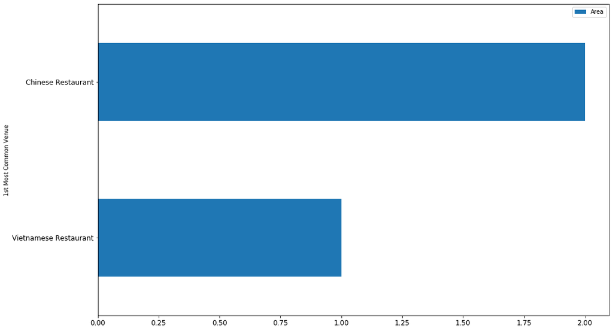

```python
cluster_6 = show_cluster_inf(hcmc_venues_merged, 5, 5)
```

```python
cluster_6
```

|  | Area | Cluster Labels | 1st Most Common Venue | 2nd Most Common Venue | 3rd Most Common Venue | 4th Most Common Venue | 5th Most Common Venue | 6th Most Common Venue | 7th Most Common Venue | 8th Most Common Venue | 9th Most Common Venue | 10th Most Common Venue | 11th Most Common Venue | 12th Most Common Venue | 13th Most Common Venue | 14th Most Common Venue | 15th Most Common Venue | 16th Most Common Venue | 17th Most Common Venue | 18th Most Common Venue | 19th Most Common Venue | 20th Most Common Venue |
| --- | --- | --- | --- | --- | --- | --- | --- | --- | --- | --- | --- | --- | --- | --- | --- | --- | --- | --- | --- | --- | --- | --- |
| 195 | Phường 9, Quận 5 | 5.0 | Vietnamese Restaurant | Café | Chinese Restaurant | Noodle House | Japanese Restaurant | Bakery | Bar | Dessert Shop | Fast Food Restaurant | Hotel | Hotpot Restaurant | Vegetarian / Vegan Restaurant | Ice Cream Shop | Asian Restaurant | Seafood Restaurant | Market | Spa | BBQ Joint | Thai Restaurant | Supermarket |
| 199 | Phường 8, Quận 5 | 5.0 | Chinese Restaurant | Café | Vietnamese Restaurant | Noodle House | Dessert Shop | Hotel | Hotpot Restaurant | Market | Asian Restaurant | Seafood Restaurant | Thai Restaurant | Pizza Place | Steakhouse | BBQ Joint | Bakery | Bar | Bookstore | Breakfast Spot | Supermarket | Convenience Store |
| 201 | Phường 7, Quận 5 | 5.0 | Chinese Restaurant | Vietnamese Restaurant | Noodle House | Market | Breakfast Spot | Café | Dessert Shop | Fast Food Restaurant | Hotel | Vegetarian / Vegan Restaurant | Asian Restaurant | Thai Restaurant | Multiplex | Pizza Place | BBQ Joint | Bakery | Bar | Bookstore | Supermarket | Steakhouse |

###### Cluster 7

```
Number of Area in the cluster: 8
```

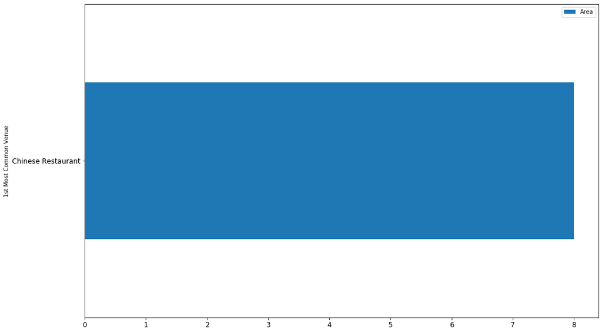

```python
cluster_7 = show_cluster_inf(hcmc_venues_merged, 6, 5)
```

```python
cluster_7
```

|  | Area | Cluster Labels | 1st Most Common Venue | 2nd Most Common Venue | 3rd Most Common Venue | 4th Most Common Venue | 5th Most Common Venue | 6th Most Common Venue | 7th Most Common Venue | 8th Most Common Venue | 9th Most Common Venue | 10th Most Common Venue | 11th Most Common Venue | 12th Most Common Venue | 13th Most Common Venue | 14th Most Common Venue | 15th Most Common Venue | 16th Most Common Venue | 17th Most Common Venue | 18th Most Common Venue | 19th Most Common Venue | 20th Most Common Venue |
| --- | --- | --- | --- | --- | --- | --- | --- | --- | --- | --- | --- | --- | --- | --- | --- | --- | --- | --- | --- | --- | --- | --- |
| 174 | Phường 6, Quận 11 | 6.0 | Chinese Restaurant | Food | Vietnamese Restaurant | Hotpot Restaurant | BBQ Joint | Bakery | Bar | Bookstore | Breakfast Spot | Café | Convenience Store | Dessert Shop | Fast Food Restaurant | Gym / Fitness Center | Hotel | Ice Cream Shop | Vegetarian / Vegan Restaurant | Japanese Restaurant | Korean Restaurant | Market |
| 175 | Phường 4, Quận 11 | 6.0 | Chinese Restaurant | Seafood Restaurant | Café | Food | Vietnamese Restaurant | Hotpot Restaurant | BBQ Joint | Bakery | Bar | Bookstore | Breakfast Spot | Convenience Store | Dessert Shop | Fast Food Restaurant | Gym / Fitness Center | Hotel | Ice Cream Shop | Vegetarian / Vegan Restaurant | Japanese Restaurant | Korean Restaurant |
| 197 | Phường 12, Quận 5 | 6.0 | Chinese Restaurant | Café | Vietnamese Restaurant | Seafood Restaurant | Dessert Shop | Gym / Fitness Center | Multiplex | Asian Restaurant | Supermarket | Restaurant | Fast Food Restaurant | BBQ Joint | Bakery | Bar | Bookstore | Breakfast Spot | Thai Restaurant | Convenience Store | Steakhouse | Food |
| 200 | Phường 15, Quận 5 | 6.0 | Chinese Restaurant | Seafood Restaurant | Café | Multiplex | Food | Vietnamese Restaurant | Hotel | BBQ Joint | Bakery | Bar | Bookstore | Breakfast Spot | Convenience Store | Dessert Shop | Fast Food Restaurant | Gym / Fitness Center | Ice Cream Shop | Hotpot Restaurant | Vegetarian / Vegan Restaurant | Japanese Restaurant |
| 203 | Phường 11, Quận 5 | 6.0 | Chinese Restaurant | Vietnamese Restaurant | Café | Dessert Shop | Multiplex | Food | Gym / Fitness Center | Hotpot Restaurant | BBQ Joint | Bakery | Bar | Bookstore | Breakfast Spot | Convenience Store | Fast Food Restaurant | Hotel | Ice Cream Shop | Vegetarian / Vegan Restaurant | Japanese Restaurant | Korean Restaurant |
| 204 | Phường 14, Quận 5 | 6.0 | Chinese Restaurant | Dessert Shop | Market | Multiplex | Seafood Restaurant | Vietnamese Restaurant | Food | Fast Food Restaurant | Convenience Store | Café | Hotel | Breakfast Spot | Bookstore | Bar | Bakery | BBQ Joint | Gym / Fitness Center | Ice Cream Shop | Hotpot Restaurant | Vegetarian / Vegan Restaurant |
| 207 | Phường 10, Quận 5 | 6.0 | Chinese Restaurant | Café | Vietnamese Restaurant | Breakfast Spot | Dessert Shop | Multiplex | Food | Japanese Restaurant | Gym / Fitness Center | Hotel | BBQ Joint | Bakery | Bar | Bookstore | Convenience Store | Fast Food Restaurant | Ice Cream Shop | Hotpot Restaurant | Vegetarian / Vegan Restaurant | Korean Restaurant |
| 208 | Phường 13, Quận 5 | 6.0 | Chinese Restaurant | Market | Food | Fast Food Restaurant | Dessert Shop | Multiplex | Café | Noodle House | Convenience Store | Vietnamese Restaurant | Hotel | Breakfast Spot | Bookstore | Bar | Bakery | BBQ Joint | Gym / Fitness Center | Ice Cream Shop | Hotpot Restaurant | Vegetarian / Vegan Restaurant |

###### Cluster 8

```
Number of Area in the cluster: 16
```

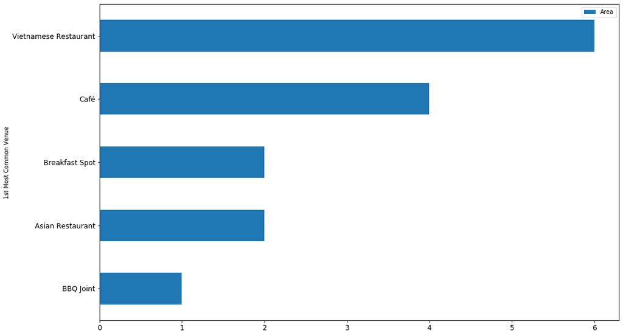

```python
cluster_8 = show_cluster_inf(hcmc_venues_merged, 7, 5)
```

```python
cluster_8
```

|  | Area | Cluster Labels | 1st Most Common Venue | 2nd Most Common Venue | 3rd Most Common Venue | 4th Most Common Venue | 5th Most Common Venue | 6th Most Common Venue | 7th Most Common Venue | 8th Most Common Venue | 9th Most Common Venue | 10th Most Common Venue | 11th Most Common Venue | 12th Most Common Venue | 13th Most Common Venue | 14th Most Common Venue | 15th Most Common Venue | 16th Most Common Venue | 17th Most Common Venue | 18th Most Common Venue | 19th Most Common Venue | 20th Most Common Venue |
| --- | --- | --- | --- | --- | --- | --- | --- | --- | --- | --- | --- | --- | --- | --- | --- | --- | --- | --- | --- | --- | --- | --- |
| 0 | Phường Tân Định, Quận 1 | 7.0 | Vietnamese Restaurant | Café | Vegetarian / Vegan Restaurant | Breakfast Spot | Asian Restaurant | Spa | Food | Bar | Market | Snack Place | BBQ Joint | Bakery | Bookstore | Thai Restaurant | Supermarket | Chinese Restaurant | Convenience Store | Dessert Shop | Fast Food Restaurant | Gym / Fitness Center |
| 44 | Phường Phước Bình, Quận 9 | 7.0 | Vietnamese Restaurant | Breakfast Spot | Hotpot Restaurant | BBQ Joint | Bakery | Bar | Bookstore | Café | Chinese Restaurant | Convenience Store | Dessert Shop | Fast Food Restaurant | Food | Gym / Fitness Center | Hotel | Ice Cream Shop | Vegetarian / Vegan Restaurant | Japanese Restaurant | Korean Restaurant | Market |
| 69 | Phường 7, Quận Bình Thạnh | 7.0 | Café | Breakfast Spot | Food | Vietnamese Restaurant | Hotpot Restaurant | BBQ Joint | Bakery | Bar | Bookstore | Chinese Restaurant | Convenience Store | Dessert Shop | Fast Food Restaurant | Gym / Fitness Center | Hotel | Ice Cream Shop | Vegetarian / Vegan Restaurant | Japanese Restaurant | Korean Restaurant | Market |
| 72 | Phường 14, Quận Bình Thạnh | 7.0 | BBQ Joint | Breakfast Spot | Seafood Restaurant | Restaurant | Café | Vietnamese Restaurant | Hotel | Bakery | Bar | Bookstore | Chinese Restaurant | Convenience Store | Dessert Shop | Fast Food Restaurant | Food | Gym / Fitness Center | Ice Cream Shop | Hotpot Restaurant | Vegetarian / Vegan Restaurant | Japanese Restaurant |
| 89 | Phường 7, Quận Tân Bình | 7.0 | Seafood Restaurant | Breakfast Spot | Market | Vietnamese Restaurant | Hotel | BBQ Joint | Bakery | Bar | Bookstore | Café | Chinese Restaurant | Convenience Store | Dessert Shop | Fast Food Restaurant | Food | Gym / Fitness Center | Ice Cream Shop | Hotpot Restaurant | Vegetarian / Vegan Restaurant | Japanese Restaurant |
| 92 | Phường 6, Quận Tân Bình | 7.0 | Breakfast Spot | Seafood Restaurant | Market | Vietnamese Restaurant | Hotel | BBQ Joint | Bakery | Bar | Bookstore | Café | Chinese Restaurant | Convenience Store | Dessert Shop | Fast Food Restaurant | Food | Gym / Fitness Center | Ice Cream Shop | Hotpot Restaurant | Vegetarian / Vegan Restaurant | Japanese Restaurant |
| 115 | Phường 8, Quận Phú Nhuận | 7.0 | Café | Hotel | Chinese Restaurant | Vietnamese Restaurant | Japanese Restaurant | Bar | Breakfast Spot | Gym / Fitness Center | Asian Restaurant | Pizza Place | Noodle House | BBQ Joint | Bakery | Thai Restaurant | Bookstore | Supermarket | Steakhouse | Spa | Convenience Store | Dessert Shop |
| 117 | Phường 10, Quận Phú Nhuận | 7.0 | Café | Vietnamese Restaurant | Chinese Restaurant | Hotel | Bar | Breakfast Spot | Noodle House | Japanese Restaurant | Gym / Fitness Center | BBQ Joint | Bakery | Bookstore | Convenience Store | Dessert Shop | Fast Food Restaurant | Food | Ice Cream Shop | Hotpot Restaurant | Vegetarian / Vegan Restaurant | Korean Restaurant |
| 135 | Phường 7, Quận 3 | 7.0 | Vietnamese Restaurant | Café | Asian Restaurant | Spa | BBQ Joint | Seafood Restaurant | Restaurant | Noodle House | Bar | Breakfast Spot | Supermarket | Food | Bakery | Bookstore | Thai Restaurant | Chinese Restaurant | Convenience Store | Dessert Shop | Fast Food Restaurant | Hotel |
| 194 | Phường 4, Quận 5 | 7.0 | Vietnamese Restaurant | Hotel | Café | Food | Asian Restaurant | Bar | Breakfast Spot | Spa | Snack Place | BBQ Joint | Bakery | Bookstore | Thai Restaurant | Chinese Restaurant | Convenience Store | Dessert Shop | Fast Food Restaurant | Supermarket | Gym / Fitness Center | Steakhouse |
| 196 | Phường 3, Quận 5 | 7.0 | Vietnamese Restaurant | Chinese Restaurant | Food | Asian Restaurant | Hotel | Noodle House | Breakfast Spot | Café | Gym / Fitness Center | BBQ Joint | Bakery | Bar | Bookstore | Thai Restaurant | Convenience Store | Dessert Shop | Fast Food Restaurant | Supermarket | Steakhouse | Spa |
| 198 | Phường 2, Quận 5 | 7.0 | Café | Chinese Restaurant | Vietnamese Restaurant | Food | Seafood Restaurant | Asian Restaurant | Fast Food Restaurant | Noodle House | Hotel | Dessert Shop | Snack Place | BBQ Joint | Bakery | Bar | Bookstore | Breakfast Spot | Thai Restaurant | Supermarket | Convenience Store | Gym / Fitness Center |
| 218 | Phường 4, Quận 6 | 7.0 | Breakfast Spot | Café | Chinese Restaurant | Pizza Place | Vietnamese Restaurant | Hotpot Restaurant | BBQ Joint | Bakery | Bar | Bookstore | Convenience Store | Dessert Shop | Fast Food Restaurant | Food | Gym / Fitness Center | Hotel | Ice Cream Shop | Vegetarian / Vegan Restaurant | Japanese Restaurant | Korean Restaurant |
| 219 | Phường 8, Quận 6 | 7.0 | Asian Restaurant | Breakfast Spot | Café | Food | Hotpot Restaurant | BBQ Joint | Bakery | Bar | Bookstore | Chinese Restaurant | Convenience Store | Dessert Shop | Fast Food Restaurant | Gym / Fitness Center | Hotel | Vietnamese Restaurant | Vegetarian / Vegan Restaurant | Japanese Restaurant | Korean Restaurant | Market |
| 228 | Phường 9, Quận 8 | 7.0 | Vietnamese Restaurant | Breakfast Spot | Seafood Restaurant | Food | Hotpot Restaurant | BBQ Joint | Bakery | Bar | Bookstore | Café | Chinese Restaurant | Convenience Store | Dessert Shop | Fast Food Restaurant | Gym / Fitness Center | Hotel | Ice Cream Shop | Vegetarian / Vegan Restaurant | Japanese Restaurant | Korean Restaurant |
| 230 | Phường 4, Quận 8 | 7.0 | Asian Restaurant | Breakfast Spot | Seafood Restaurant | Café | Hotpot Restaurant | BBQ Joint | Bakery | Bar | Bookstore | Chinese Restaurant | Convenience Store | Dessert Shop | Fast Food Restaurant | Food | Gym / Fitness Center | Hotel | Vietnamese Restaurant | Vegetarian / Vegan Restaurant | Japanese Restaurant | Korean Restaurant |

###### Cluster 9

```
Number of Area in the cluster: 1
```

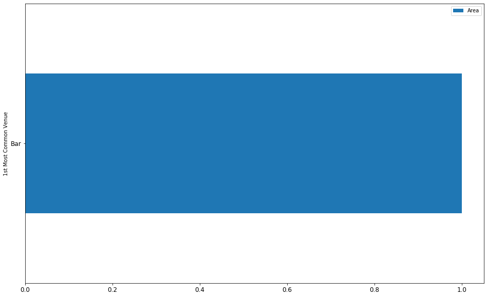

```python
cluster_9 = show_cluster_inf(hcmc_venues_merged, 8, 5)
```

```python
cluster_9
```

|  | Area | Cluster Labels | 1st Most Common Venue | 2nd Most Common Venue | 3rd Most Common Venue | 4th Most Common Venue | 5th Most Common Venue | 6th Most Common Venue | 7th Most Common Venue | 8th Most Common Venue | 9th Most Common Venue | 10th Most Common Venue | 11th Most Common Venue | 12th Most Common Venue | 13th Most Common Venue | 14th Most Common Venue | 15th Most Common Venue | 16th Most Common Venue | 17th Most Common Venue | 18th Most Common Venue | 19th Most Common Venue | 20th Most Common Venue |
| --- | --- | --- | --- | --- | --- | --- | --- | --- | --- | --- | --- | --- | --- | --- | --- | --- | --- | --- | --- | --- | --- | --- |
| 2 | Phường Bến Nghé, Quận 1 | 8.0 | Bar | Hotel | Café | Spa | Vietnamese Restaurant | Restaurant | Korean Restaurant | BBQ Joint | Convenience Store | Dessert Shop | Gym / Fitness Center | Asian Restaurant | Thai Restaurant | Noodle House | Pizza Place | Steakhouse | Market | Chinese Restaurant | Bakery | Supermarket |

###### Cluster 10

```
Number of Area in the cluster: 2
```

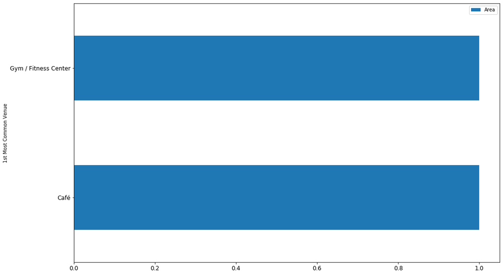

```python
cluster_10 = show_cluster_inf(hcmc_venues_merged, 9, 5)
```

```python
cluster_10
```

|  | Area | Cluster Labels | 1st Most Common Venue | 2nd Most Common Venue | 3rd Most Common Venue | 4th Most Common Venue | 5th Most Common Venue | 6th Most Common Venue | 7th Most Common Venue | 8th Most Common Venue | 9th Most Common Venue | 10th Most Common Venue | 11th Most Common Venue | 12th Most Common Venue | 13th Most Common Venue | 14th Most Common Venue | 15th Most Common Venue | 16th Most Common Venue | 17th Most Common Venue | 18th Most Common Venue | 19th Most Common Venue | 20th Most Common Venue |
| --- | --- | --- | --- | --- | --- | --- | --- | --- | --- | --- | --- | --- | --- | --- | --- | --- | --- | --- | --- | --- | --- | --- |
| 79 | Phường 22, Quận Bình Thạnh | 9.0 | Gym / Fitness Center | Café | Bakery | Restaurant | Thai Restaurant | Multiplex | Convenience Store | Fast Food Restaurant | BBQ Joint | Bar | Bookstore | Breakfast Spot | Hotel | Chinese Restaurant | Dessert Shop | Food | Vietnamese Restaurant | Ice Cream Shop | Hotpot Restaurant | Vegetarian / Vegan Restaurant |
| 257 | Phường Tân Phong, Quận 7 | 9.0 | Café | Fast Food Restaurant | Vietnamese Restaurant | Multiplex | BBQ Joint | Bakery | Chinese Restaurant | Dessert Shop | Gym / Fitness Center | Japanese Restaurant | Korean Restaurant | Asian Restaurant | Thai Restaurant | Supermarket | Market | Convenience Store | Bar | Bookstore | Breakfast Spot | Steakhouse |

###### Cluster 11

```
Number of Area in the cluster: 149
```

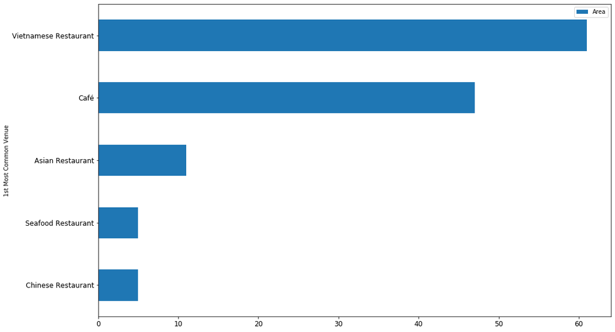

```python
cluster_11 = show_cluster_inf(hcmc_venues_merged, 10, 5)
```

```python
cluster_11
```

|  | Area | Cluster Labels | 1st Most Common Venue | 2nd Most Common Venue | 3rd Most Common Venue | 4th Most Common Venue | 5th Most Common Venue | 6th Most Common Venue | 7th Most Common Venue | 8th Most Common Venue | 9th Most Common Venue | 10th Most Common Venue | 11th Most Common Venue | 12th Most Common Venue | 13th Most Common Venue | 14th Most Common Venue | 15th Most Common Venue | 16th Most Common Venue | 17th Most Common Venue | 18th Most Common Venue | 19th Most Common Venue | 20th Most Common Venue |
| --- | --- | --- | --- | --- | --- | --- | --- | --- | --- | --- | --- | --- | --- | --- | --- | --- | --- | --- | --- | --- | --- | --- |
| 10 | Phường Thạnh Xuân, Quận 12 | 10.0 | Café | Vietnamese Restaurant | Hotpot Restaurant | BBQ Joint | Bakery | Bar | Bookstore | Breakfast Spot | Chinese Restaurant | Convenience Store | Dessert Shop | Fast Food Restaurant | Food | Gym / Fitness Center | Hotel | Ice Cream Shop | Vegetarian / Vegan Restaurant | Japanese Restaurant | Korean Restaurant | Market |
| 11 | Phường Thạnh Lộc, Quận 12 | 10.0 | Café | Vietnamese Restaurant | Hotpot Restaurant | BBQ Joint | Bakery | Bar | Bookstore | Breakfast Spot | Chinese Restaurant | Convenience Store | Dessert Shop | Fast Food Restaurant | Food | Gym / Fitness Center | Hotel | Ice Cream Shop | Vegetarian / Vegan Restaurant | Japanese Restaurant | Korean Restaurant | Market |
| 13 | Phường Thới An, Quận 12 | 10.0 | Vietnamese Restaurant | Café | Hotpot Restaurant | BBQ Joint | Bakery | Bar | Bookstore | Breakfast Spot | Chinese Restaurant | Convenience Store | Dessert Shop | Fast Food Restaurant | Food | Gym / Fitness Center | Hotel | Ice Cream Shop | Vegetarian / Vegan Restaurant | Japanese Restaurant | Korean Restaurant | Market |
| 14 | Phường Tân Chánh Hiệp, Quận 12 | 10.0 | Café | Food | Vietnamese Restaurant | Hotpot Restaurant | BBQ Joint | Bakery | Bar | Bookstore | Breakfast Spot | Chinese Restaurant | Convenience Store | Dessert Shop | Fast Food Restaurant | Gym / Fitness Center | Hotel | Ice Cream Shop | Vegetarian / Vegan Restaurant | Japanese Restaurant | Korean Restaurant | Market |
| 15 | Phường An Phú Đông, Quận 12 | 10.0 | Vietnamese Restaurant | Hotpot Restaurant | BBQ Joint | Bakery | Bar | Bookstore | Breakfast Spot | Café | Chinese Restaurant | Convenience Store | Dessert Shop | Fast Food Restaurant | Food | Gym / Fitness Center | Hotel | Ice Cream Shop | Vegetarian / Vegan Restaurant | Japanese Restaurant | Korean Restaurant | Market |
| 16 | Phường Tân Thới Hiệp, Quận 12 | 10.0 | Café | Restaurant | Vietnamese Restaurant | Hotpot Restaurant | BBQ Joint | Bakery | Bar | Bookstore | Breakfast Spot | Chinese Restaurant | Convenience Store | Dessert Shop | Fast Food Restaurant | Food | Gym / Fitness Center | Hotel | Ice Cream Shop | Vegetarian / Vegan Restaurant | Japanese Restaurant | Korean Restaurant |
| 17 | Phường Trung Mỹ Tây, Quận 12 | 10.0 | Café | Vietnamese Restaurant | Hotpot Restaurant | BBQ Joint | Bakery | Bar | Bookstore | Breakfast Spot | Chinese Restaurant | Convenience Store | Dessert Shop | Fast Food Restaurant | Food | Gym / Fitness Center | Hotel | Ice Cream Shop | Vegetarian / Vegan Restaurant | Japanese Restaurant | Korean Restaurant | Market |
| 18 | Phường Tân Hưng Thuận, Quận 12 | 10.0 | Café | Convenience Store | Vietnamese Restaurant | Hotpot Restaurant | BBQ Joint | Bakery | Bar | Bookstore | Breakfast Spot | Chinese Restaurant | Dessert Shop | Fast Food Restaurant | Food | Gym / Fitness Center | Hotel | Ice Cream Shop | Vegetarian / Vegan Restaurant | Japanese Restaurant | Korean Restaurant | Market |
| 19 | Phường Đông Hưng Thuận, Quận 12 | 10.0 | Café | Restaurant | Hotel | Vietnamese Restaurant | Hotpot Restaurant | BBQ Joint | Bakery | Bar | Bookstore | Breakfast Spot | Chinese Restaurant | Convenience Store | Dessert Shop | Fast Food Restaurant | Food | Gym / Fitness Center | Ice Cream Shop | Vegetarian / Vegan Restaurant | Japanese Restaurant | Korean Restaurant |
| 20 | Phường Tân Thới Nhất, Quận 12 | 10.0 | Bakery | Café | Restaurant | Vietnamese Restaurant | Hotpot Restaurant | BBQ Joint | Bar | Bookstore | Breakfast Spot | Chinese Restaurant | Convenience Store | Dessert Shop | Fast Food Restaurant | Food | Gym / Fitness Center | Hotel | Ice Cream Shop | Vegetarian / Vegan Restaurant | Japanese Restaurant | Korean Restaurant |
| 21 | Phường Linh Xuân, Quận Thủ Đức | 10.0 | Vietnamese Restaurant | Restaurant | Hotpot Restaurant | BBQ Joint | Bakery | Bar | Bookstore | Breakfast Spot | Café | Chinese Restaurant | Convenience Store | Dessert Shop | Fast Food Restaurant | Food | Gym / Fitness Center | Hotel | Ice Cream Shop | Vegetarian / Vegan Restaurant | Japanese Restaurant | Korean Restaurant |
| 22 | Phường Bình Chiểu, Quận Thủ Đức | 10.0 | Restaurant | Vietnamese Restaurant | Hotpot Restaurant | BBQ Joint | Bakery | Bar | Bookstore | Breakfast Spot | Café | Chinese Restaurant | Convenience Store | Dessert Shop | Fast Food Restaurant | Food | Gym / Fitness Center | Hotel | Ice Cream Shop | Vegetarian / Vegan Restaurant | Japanese Restaurant | Korean Restaurant |
| 23 | Phường Linh Trung, Quận Thủ Đức | 10.0 | Vietnamese Restaurant | Hotpot Restaurant | BBQ Joint | Bakery | Bar | Bookstore | Breakfast Spot | Café | Chinese Restaurant | Convenience Store | Dessert Shop | Fast Food Restaurant | Food | Gym / Fitness Center | Hotel | Ice Cream Shop | Vegetarian / Vegan Restaurant | Japanese Restaurant | Korean Restaurant | Market |
| 25 | Phường Tam Phú, Quận Thủ Đức | 10.0 | Vietnamese Restaurant | Hotpot Restaurant | BBQ Joint | Bakery | Bar | Bookstore | Breakfast Spot | Café | Chinese Restaurant | Convenience Store | Dessert Shop | Fast Food Restaurant | Food | Gym / Fitness Center | Hotel | Ice Cream Shop | Vegetarian / Vegan Restaurant | Japanese Restaurant | Korean Restaurant | Market |
| 27 | Phường Hiệp Bình Chánh, Quận Thủ Đức | 10.0 | Asian Restaurant | Hotpot Restaurant | BBQ Joint | Bakery | Bar | Bookstore | Breakfast Spot | Café | Chinese Restaurant | Convenience Store | Dessert Shop | Fast Food Restaurant | Food | Gym / Fitness Center | Hotel | Vietnamese Restaurant | Vegetarian / Vegan Restaurant | Japanese Restaurant | Korean Restaurant | Market |
| 28 | Phường Linh Chiểu, Quận Thủ Đức | 10.0 | Café | Vietnamese Restaurant | Hotpot Restaurant | BBQ Joint | Bakery | Bar | Bookstore | Breakfast Spot | Chinese Restaurant | Convenience Store | Dessert Shop | Fast Food Restaurant | Food | Gym / Fitness Center | Hotel | Ice Cream Shop | Vegetarian / Vegan Restaurant | Japanese Restaurant | Korean Restaurant | Market |
| 30 | Phường Linh Đông, Quận Thủ Đức | 10.0 | Vietnamese Restaurant | Hotpot Restaurant | BBQ Joint | Bakery | Bar | Bookstore | Breakfast Spot | Café | Chinese Restaurant | Convenience Store | Dessert Shop | Fast Food Restaurant | Food | Gym / Fitness Center | Hotel | Ice Cream Shop | Vegetarian / Vegan Restaurant | Japanese Restaurant | Korean Restaurant | Market |
| 32 | Phường Trường Thọ, Quận Thủ Đức | 10.0 | Vietnamese Restaurant | Hotpot Restaurant | BBQ Joint | Bakery | Bar | Bookstore | Breakfast Spot | Café | Chinese Restaurant | Convenience Store | Dessert Shop | Fast Food Restaurant | Food | Gym / Fitness Center | Hotel | Ice Cream Shop | Vegetarian / Vegan Restaurant | Japanese Restaurant | Korean Restaurant | Market |
| 33 | Phường Long Bình, Quận 9 | 10.0 | Café | Vietnamese Restaurant | Hotpot Restaurant | BBQ Joint | Bakery | Bar | Bookstore | Breakfast Spot | Chinese Restaurant | Convenience Store | Dessert Shop | Fast Food Restaurant | Food | Gym / Fitness Center | Hotel | Ice Cream Shop | Vegetarian / Vegan Restaurant | Japanese Restaurant | Korean Restaurant | Market |
| 34 | Phường Long Thạnh Mỹ, Quận 9 | 10.0 | Vietnamese Restaurant | Café | Hotpot Restaurant | BBQ Joint | Bakery | Bar | Bookstore | Breakfast Spot | Chinese Restaurant | Convenience Store | Dessert Shop | Fast Food Restaurant | Food | Gym / Fitness Center | Hotel | Ice Cream Shop | Vegetarian / Vegan Restaurant | Japanese Restaurant | Korean Restaurant | Market |
| 35 | Phường Tân Phú, Quận 9 | 10.0 | Food | Vietnamese Restaurant | Hotpot Restaurant | BBQ Joint | Bakery | Bar | Bookstore | Breakfast Spot | Café | Chinese Restaurant | Convenience Store | Dessert Shop | Fast Food Restaurant | Gym / Fitness Center | Hotel | Ice Cream Shop | Vegetarian / Vegan Restaurant | Japanese Restaurant | Korean Restaurant | Market |
| 37 | Phường Tăng Nhơn Phú A, Quận 9 | 10.0 | Asian Restaurant | Bakery | Noodle House | Hotpot Restaurant | BBQ Joint | Bar | Bookstore | Breakfast Spot | Café | Chinese Restaurant | Convenience Store | Dessert Shop | Fast Food Restaurant | Food | Gym / Fitness Center | Hotel | Vietnamese Restaurant | Vegetarian / Vegan Restaurant | Japanese Restaurant | Korean Restaurant |
| 38 | Phường Tăng Nhơn Phú B, Quận 9 | 10.0 | Vietnamese Restaurant | BBQ Joint | Restaurant | Hotpot Restaurant | Bakery | Bar | Bookstore | Breakfast Spot | Café | Chinese Restaurant | Convenience Store | Dessert Shop | Fast Food Restaurant | Food | Gym / Fitness Center | Hotel | Ice Cream Shop | Vegetarian / Vegan Restaurant | Japanese Restaurant | Korean Restaurant |
| 39 | Phường Phước Long B, Quận 9 | 10.0 | Café | Vietnamese Restaurant | Hotpot Restaurant | BBQ Joint | Bakery | Bar | Bookstore | Breakfast Spot | Chinese Restaurant | Convenience Store | Dessert Shop | Fast Food Restaurant | Food | Gym / Fitness Center | Hotel | Ice Cream Shop | Vegetarian / Vegan Restaurant | Japanese Restaurant | Korean Restaurant | Market |
| 40 | Phường Phước Long A, Quận 9 | 10.0 | Vietnamese Restaurant | Hotpot Restaurant | BBQ Joint | Bakery | Bar | Bookstore | Breakfast Spot | Café | Chinese Restaurant | Convenience Store | Dessert Shop | Fast Food Restaurant | Food | Gym / Fitness Center | Hotel | Ice Cream Shop | Vegetarian / Vegan Restaurant | Japanese Restaurant | Korean Restaurant | Market |
| 42 | Phường Long Phước, Quận 9 | 10.0 | Convenience Store | Vietnamese Restaurant | Hotpot Restaurant | BBQ Joint | Bakery | Bar | Bookstore | Breakfast Spot | Café | Chinese Restaurant | Dessert Shop | Fast Food Restaurant | Food | Gym / Fitness Center | Hotel | Ice Cream Shop | Vegetarian / Vegan Restaurant | Japanese Restaurant | Korean Restaurant | Market |
| 46 | Phường 15, Quận Gò Vấp | 10.0 | Asian Restaurant | Food | Hotpot Restaurant | BBQ Joint | Bakery | Bar | Bookstore | Breakfast Spot | Café | Chinese Restaurant | Convenience Store | Dessert Shop | Fast Food Restaurant | Gym / Fitness Center | Hotel | Vietnamese Restaurant | Vegetarian / Vegan Restaurant | Japanese Restaurant | Korean Restaurant | Market |
| 47 | Phường 13, Quận Gò Vấp | 10.0 | Café | Vietnamese Restaurant | Hotpot Restaurant | BBQ Joint | Bakery | Bar | Bookstore | Breakfast Spot | Chinese Restaurant | Convenience Store | Dessert Shop | Fast Food Restaurant | Food | Gym / Fitness Center | Hotel | Ice Cream Shop | Vegetarian / Vegan Restaurant | Japanese Restaurant | Korean Restaurant | Market |
| 48 | Phường 17, Quận Gò Vấp | 10.0 | Seafood Restaurant | Café | Vietnamese Restaurant | Hotpot Restaurant | BBQ Joint | Bakery | Bar | Bookstore | Breakfast Spot | Chinese Restaurant | Convenience Store | Dessert Shop | Fast Food Restaurant | Food | Gym / Fitness Center | Hotel | Ice Cream Shop | Vegetarian / Vegan Restaurant | Japanese Restaurant | Korean Restaurant |
| 49 | Phường 6, Quận Gò Vấp | 10.0 | Noodle House | Seafood Restaurant | Café | Food | Vietnamese Restaurant | Hotel | BBQ Joint | Bakery | Bar | Bookstore | Breakfast Spot | Chinese Restaurant | Convenience Store | Dessert Shop | Fast Food Restaurant | Gym / Fitness Center | Ice Cream Shop | Hotpot Restaurant | Vegetarian / Vegan Restaurant | Japanese Restaurant |

[output cut: 119 more lines]

###### Cluster 12

```
Number of Area in the cluster: 1
```

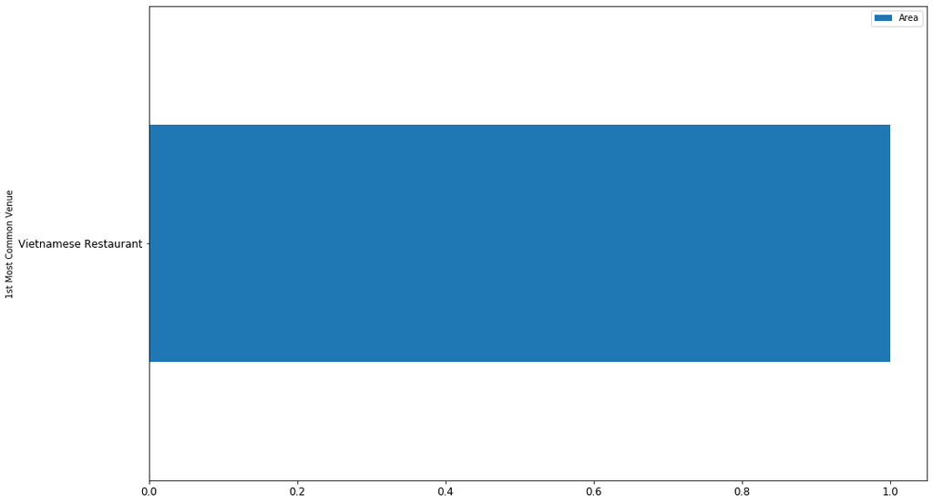

```python
cluster_12 = show_cluster_inf(hcmc_venues_merged, 11, 5)
```

```python
cluster_12
```

|  | Area | Cluster Labels | 1st Most Common Venue | 2nd Most Common Venue | 3rd Most Common Venue | 4th Most Common Venue | 5th Most Common Venue | 6th Most Common Venue | 7th Most Common Venue | 8th Most Common Venue | 9th Most Common Venue | 10th Most Common Venue | 11th Most Common Venue | 12th Most Common Venue | 13th Most Common Venue | 14th Most Common Venue | 15th Most Common Venue | 16th Most Common Venue | 17th Most Common Venue | 18th Most Common Venue | 19th Most Common Venue | 20th Most Common Venue |
| --- | --- | --- | --- | --- | --- | --- | --- | --- | --- | --- | --- | --- | --- | --- | --- | --- | --- | --- | --- | --- | --- | --- |
| 146 | Phường 2, Quận 3 | 11.0 | Vietnamese Restaurant | Café | Bakery | Food | Asian Restaurant | Dessert Shop | Bookstore | Japanese Restaurant | Pizza Place | Noodle House | Hotel | Hotpot Restaurant | Convenience Store | Bar | Snack Place | Chinese Restaurant | Vegetarian / Vegan Restaurant | Market | Restaurant | Seafood Restaurant |

###### Cluster 13

```
Number of Area in the cluster: 1
```

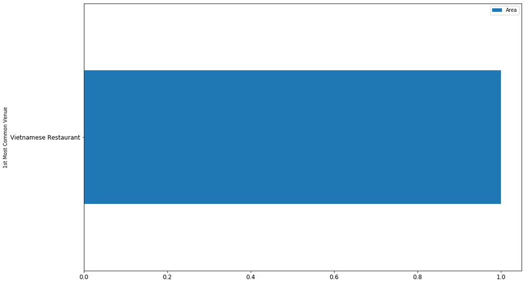

```python
cluster_13 = show_cluster_inf(hcmc_venues_merged, 12, 5)
```

```python
cluster_13
```

|  | Area | Cluster Labels | 1st Most Common Venue | 2nd Most Common Venue | 3rd Most Common Venue | 4th Most Common Venue | 5th Most Common Venue | 6th Most Common Venue | 7th Most Common Venue | 8th Most Common Venue | 9th Most Common Venue | 10th Most Common Venue | 11th Most Common Venue | 12th Most Common Venue | 13th Most Common Venue | 14th Most Common Venue | 15th Most Common Venue | 16th Most Common Venue | 17th Most Common Venue | 18th Most Common Venue | 19th Most Common Venue | 20th Most Common Venue |
| --- | --- | --- | --- | --- | --- | --- | --- | --- | --- | --- | --- | --- | --- | --- | --- | --- | --- | --- | --- | --- | --- | --- |
| 1 | Phường Đa Kao, Quận 1 | 12.0 | Vietnamese Restaurant | Café | Japanese Restaurant | Vegetarian / Vegan Restaurant | BBQ Joint | Bakery | Breakfast Spot | Dessert Shop | Asian Restaurant | Restaurant | Fast Food Restaurant | Gym / Fitness Center | Bar | Steakhouse | Spa | Chinese Restaurant | Noodle House | Ice Cream Shop | Hotel | Seafood Restaurant |

###### Cluster 14

```
Number of Area in the cluster: 29
```

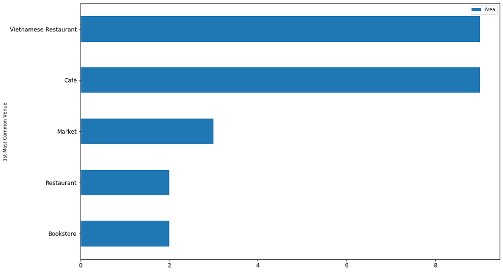

```python
cluster_14 = show_cluster_inf(hcmc_venues_merged, 13, 5)
```

```python
cluster_14
```

|  | Area | Cluster Labels | 1st Most Common Venue | 2nd Most Common Venue | 3rd Most Common Venue | 4th Most Common Venue | 5th Most Common Venue | 6th Most Common Venue | 7th Most Common Venue | 8th Most Common Venue | 9th Most Common Venue | 10th Most Common Venue | 11th Most Common Venue | 12th Most Common Venue | 13th Most Common Venue | 14th Most Common Venue | 15th Most Common Venue | 16th Most Common Venue | 17th Most Common Venue | 18th Most Common Venue | 19th Most Common Venue | 20th Most Common Venue |
| --- | --- | --- | --- | --- | --- | --- | --- | --- | --- | --- | --- | --- | --- | --- | --- | --- | --- | --- | --- | --- | --- | --- |
| 24 | Phường Tam Bình, Quận Thủ Đức | 13.0 | Vietnamese Restaurant | Bookstore | Café | Market | Hotpot Restaurant | BBQ Joint | Bakery | Bar | Breakfast Spot | Chinese Restaurant | Convenience Store | Dessert Shop | Fast Food Restaurant | Food | Gym / Fitness Center | Hotel | Ice Cream Shop | Vegetarian / Vegan Restaurant | Japanese Restaurant | Korean Restaurant |
| 43 | Phường Long Trường, Quận 9 | 13.0 | Market | Vietnamese Restaurant | Hotpot Restaurant | BBQ Joint | Bakery | Bar | Bookstore | Breakfast Spot | Café | Chinese Restaurant | Convenience Store | Dessert Shop | Fast Food Restaurant | Food | Gym / Fitness Center | Hotel | Ice Cream Shop | Vegetarian / Vegan Restaurant | Japanese Restaurant | Korean Restaurant |
| 52 | Phường 14, Quận Gò Vấp | 13.0 | Market | Vietnamese Restaurant | Hotpot Restaurant | BBQ Joint | Bakery | Bar | Bookstore | Breakfast Spot | Café | Chinese Restaurant | Convenience Store | Dessert Shop | Fast Food Restaurant | Food | Gym / Fitness Center | Hotel | Ice Cream Shop | Vegetarian / Vegan Restaurant | Japanese Restaurant | Korean Restaurant |
| 61 | Phường 3, Quận Gò Vấp | 13.0 | Market | Café | Noodle House | Vietnamese Restaurant | Hotel | BBQ Joint | Bakery | Bar | Bookstore | Breakfast Spot | Chinese Restaurant | Convenience Store | Dessert Shop | Fast Food Restaurant | Food | Gym / Fitness Center | Ice Cream Shop | Hotpot Restaurant | Vegetarian / Vegan Restaurant | Japanese Restaurant |
| 87 | Phường 3, Quận Tân Bình | 13.0 | Vietnamese Restaurant | Café | Noodle House | Chinese Restaurant | Hotel | Market | Ice Cream Shop | Seafood Restaurant | Restaurant | BBQ Joint | Bakery | Bar | Bookstore | Breakfast Spot | Thai Restaurant | Supermarket | Convenience Store | Dessert Shop | Fast Food Restaurant | Food |
| 88 | Phường 11, Quận Tân Bình | 13.0 | Vietnamese Restaurant | Bakery | Noodle House | Market | Hotel | BBQ Joint | Bar | Bookstore | Breakfast Spot | Café | Chinese Restaurant | Convenience Store | Dessert Shop | Fast Food Restaurant | Food | Gym / Fitness Center | Ice Cream Shop | Hotpot Restaurant | Vegetarian / Vegan Restaurant | Japanese Restaurant |
| 93 | Phường 8, Quận Tân Bình | 13.0 | Fast Food Restaurant | Market | Vietnamese Restaurant | Hotpot Restaurant | BBQ Joint | Bakery | Bar | Bookstore | Breakfast Spot | Café | Chinese Restaurant | Convenience Store | Dessert Shop | Food | Gym / Fitness Center | Hotel | Ice Cream Shop | Vegetarian / Vegan Restaurant | Japanese Restaurant | Korean Restaurant |
| 95 | Phường 14, Quận Tân Bình | 13.0 | Vietnamese Restaurant | Market | Japanese Restaurant | Hotel | BBQ Joint | Bakery | Bar | Bookstore | Breakfast Spot | Café | Chinese Restaurant | Convenience Store | Dessert Shop | Fast Food Restaurant | Food | Gym / Fitness Center | Ice Cream Shop | Hotpot Restaurant | Vegetarian / Vegan Restaurant | Korean Restaurant |
| 100 | Phường Tân Quý, Quận Tân Phú | 13.0 | Café | Restaurant | Market | Vietnamese Restaurant | Hotel | BBQ Joint | Bakery | Bar | Bookstore | Breakfast Spot | Chinese Restaurant | Convenience Store | Dessert Shop | Fast Food Restaurant | Food | Gym / Fitness Center | Ice Cream Shop | Hotpot Restaurant | Vegetarian / Vegan Restaurant | Japanese Restaurant |
| 101 | Phường Tân Thành, Quận Tân Phú | 13.0 | Café | Pizza Place | Market | Snack Place | Food | Fast Food Restaurant | Dessert Shop | Convenience Store | Chinese Restaurant | Vietnamese Restaurant | Hotel | Breakfast Spot | Bookstore | Bar | Bakery | BBQ Joint | Gym / Fitness Center | Ice Cream Shop | Hotpot Restaurant | Vegetarian / Vegan Restaurant |
| 102 | Phường Phú Thọ Hòa, Quận Tân Phú | 13.0 | Restaurant | Market | Fast Food Restaurant | Vietnamese Restaurant | Hotel | BBQ Joint | Bakery | Bar | Bookstore | Breakfast Spot | Café | Chinese Restaurant | Convenience Store | Dessert Shop | Food | Gym / Fitness Center | Ice Cream Shop | Hotpot Restaurant | Vegetarian / Vegan Restaurant | Japanese Restaurant |
| 126 | Phường Bình Trưng Đông, Quận 2 | 13.0 | Café | Market | Vietnamese Restaurant | Hotpot Restaurant | BBQ Joint | Bakery | Bar | Bookstore | Breakfast Spot | Chinese Restaurant | Convenience Store | Dessert Shop | Fast Food Restaurant | Food | Gym / Fitness Center | Hotel | Ice Cream Shop | Vegetarian / Vegan Restaurant | Japanese Restaurant | Korean Restaurant |
| 128 | Phường Bình Khánh, Quận 2 | 13.0 | Bookstore | Vietnamese Restaurant | Market | Hotpot Restaurant | BBQ Joint | Bakery | Bar | Breakfast Spot | Café | Chinese Restaurant | Convenience Store | Dessert Shop | Fast Food Restaurant | Food | Gym / Fitness Center | Hotel | Ice Cream Shop | Vegetarian / Vegan Restaurant | Japanese Restaurant | Korean Restaurant |
| 150 | Phường 14, Quận 10 | 13.0 | Café | Vietnamese Restaurant | Market | Hotpot Restaurant | BBQ Joint | Bakery | Bar | Bookstore | Breakfast Spot | Chinese Restaurant | Convenience Store | Dessert Shop | Fast Food Restaurant | Food | Gym / Fitness Center | Hotel | Ice Cream Shop | Vegetarian / Vegan Restaurant | Japanese Restaurant | Korean Restaurant |
| 163 | Phường 15, Quận 11 | 13.0 | Café | Vietnamese Restaurant | Seafood Restaurant | Market | Gym / Fitness Center | Hotel | BBQ Joint | Bakery | Bar | Bookstore | Breakfast Spot | Chinese Restaurant | Convenience Store | Dessert Shop | Fast Food Restaurant | Food | Ice Cream Shop | Hotpot Restaurant | Vegetarian / Vegan Restaurant | Japanese Restaurant |
| 164 | Phường 5, Quận 11 | 13.0 | Restaurant | Market | Vegetarian / Vegan Restaurant | Fast Food Restaurant | Gym / Fitness Center | Bookstore | Breakfast Spot | Café | Hotel | Chinese Restaurant | Convenience Store | Dessert Shop | Bar | Bakery | Food | BBQ Joint | Vietnamese Restaurant | Ice Cream Shop | Hotpot Restaurant | Japanese Restaurant |
| 168 | Phường 10, Quận 11 | 13.0 | Vietnamese Restaurant | Café | Convenience Store | Market | Hotpot Restaurant | BBQ Joint | Bakery | Bar | Bookstore | Breakfast Spot | Chinese Restaurant | Dessert Shop | Fast Food Restaurant | Food | Gym / Fitness Center | Hotel | Ice Cream Shop | Vegetarian / Vegan Restaurant | Japanese Restaurant | Korean Restaurant |
| 171 | Phường 9, Quận 11 | 13.0 | Café | Market | Vietnamese Restaurant | Hotpot Restaurant | BBQ Joint | Bakery | Bar | Bookstore | Breakfast Spot | Chinese Restaurant | Convenience Store | Dessert Shop | Fast Food Restaurant | Food | Gym / Fitness Center | Hotel | Ice Cream Shop | Vegetarian / Vegan Restaurant | Japanese Restaurant | Korean Restaurant |
| 179 | Phường 12, Quận 4 | 13.0 | Café | Vietnamese Restaurant | Seafood Restaurant | Chinese Restaurant | Market | Restaurant | Asian Restaurant | Food | BBQ Joint | Noodle House | Bar | Thai Restaurant | Fast Food Restaurant | Bakery | Bookstore | Breakfast Spot | Supermarket | Convenience Store | Dessert Shop | Snack Place |
| 180 | Phường 13, Quận 4 | 13.0 | Vietnamese Restaurant | Noodle House | BBQ Joint | Café | Market | Asian Restaurant | Snack Place | Food | Thai Restaurant | Bakery | Bar | Bookstore | Breakfast Spot | Supermarket | Chinese Restaurant | Convenience Store | Dessert Shop | Fast Food Restaurant | Gym / Fitness Center | Seafood Restaurant |
| 205 | Phường 5, Quận 5 | 13.0 | Chinese Restaurant | Noodle House | Vietnamese Restaurant | Hotel | Dessert Shop | Market | Fast Food Restaurant | Vegetarian / Vegan Restaurant | Bakery | Bar | Bookstore | Breakfast Spot | Café | Convenience Store | BBQ Joint | Food | Gym / Fitness Center | Ice Cream Shop | Hotpot Restaurant | Japanese Restaurant |
| 210 | Phường 13, Quận 6 | 13.0 | Vietnamese Restaurant | Market | Fast Food Restaurant | Food | Asian Restaurant | Spa | Snack Place | BBQ Joint | Bakery | Bar | Bookstore | Breakfast Spot | Café | Chinese Restaurant | Convenience Store | Dessert Shop | Thai Restaurant | Supermarket | Gym / Fitness Center | Hotel |
| 214 | Phường 5, Quận 6 | 13.0 | Bookstore | Pizza Place | Dessert Shop | Market | Vietnamese Restaurant | Hotel | BBQ Joint | Bakery | Bar | Breakfast Spot | Café | Chinese Restaurant | Convenience Store | Fast Food Restaurant | Food | Gym / Fitness Center | Ice Cream Shop | Hotpot Restaurant | Vegetarian / Vegan Restaurant | Japanese Restaurant |
| 216 | Phường 2, Quận 6 | 13.0 | Café | Seafood Restaurant | Chinese Restaurant | Market | Vietnamese Restaurant | Hotel | BBQ Joint | Bakery | Bar | Bookstore | Breakfast Spot | Convenience Store | Dessert Shop | Fast Food Restaurant | Food | Gym / Fitness Center | Ice Cream Shop | Hotpot Restaurant | Vegetarian / Vegan Restaurant | Japanese Restaurant |
| 217 | Phường 1, Quận 6 | 13.0 | Café | Chinese Restaurant | Noodle House | Market | Food | Vietnamese Restaurant | Hotel | BBQ Joint | Bakery | Bar | Bookstore | Breakfast Spot | Convenience Store | Dessert Shop | Fast Food Restaurant | Gym / Fitness Center | Ice Cream Shop | Hotpot Restaurant | Vegetarian / Vegan Restaurant | Japanese Restaurant |
| 258 | Phường Phú Mỹ, Quận 7 | 13.0 | Vietnamese Restaurant | Restaurant | Market | Food | Hotel | BBQ Joint | Bakery | Bar | Bookstore | Breakfast Spot | Café | Chinese Restaurant | Convenience Store | Dessert Shop | Fast Food Restaurant | Gym / Fitness Center | Ice Cream Shop | Hotpot Restaurant | Vegetarian / Vegan Restaurant | Japanese Restaurant |
| 280 | Thị trấn Hóc Môn, Huyện Hóc Môn | 13.0 | Seafood Restaurant | Café | Market | Noodle House | Chinese Restaurant | Food | Fast Food Restaurant | Dessert Shop | Convenience Store | Vietnamese Restaurant | Hotel | Breakfast Spot | Bookstore | Bar | Bakery | BBQ Joint | Gym / Fitness Center | Ice Cream Shop | Hotpot Restaurant | Vegetarian / Vegan Restaurant |
| 291 | Xã Bà Điểm, Huyện Hóc Môn | 13.0 | Vietnamese Restaurant | Market | Hotpot Restaurant | BBQ Joint | Bakery | Bar | Bookstore | Breakfast Spot | Café | Chinese Restaurant | Convenience Store | Dessert Shop | Fast Food Restaurant | Food | Gym / Fitness Center | Hotel | Ice Cream Shop | Vegetarian / Vegan Restaurant | Japanese Restaurant | Korean Restaurant |
| 292 | Thị trấn Tân Túc, Huyện Bình Chánh | 13.0 | Bakery | Market | Vietnamese Restaurant | Hotpot Restaurant | BBQ Joint | Bar | Bookstore | Breakfast Spot | Café | Chinese Restaurant | Convenience Store | Dessert Shop | Fast Food Restaurant | Food | Gym / Fitness Center | Hotel | Ice Cream Shop | Vegetarian / Vegan Restaurant | Japanese Restaurant | Korean Restaurant |

###### Cluster 15

```
Number of Area in the cluster: 7
```

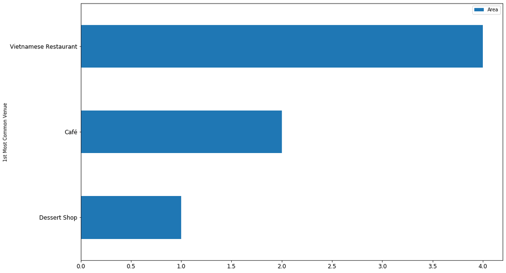

```python
cluster_15 = show_cluster_inf(hcmc_venues_merged, 14, 5)
```

```python
cluster_15
```

|  | Area | Cluster Labels | 1st Most Common Venue | 2nd Most Common Venue | 3rd Most Common Venue | 4th Most Common Venue | 5th Most Common Venue | 6th Most Common Venue | 7th Most Common Venue | 8th Most Common Venue | 9th Most Common Venue | 10th Most Common Venue | 11th Most Common Venue | 12th Most Common Venue | 13th Most Common Venue | 14th Most Common Venue | 15th Most Common Venue | 16th Most Common Venue | 17th Most Common Venue | 18th Most Common Venue | 19th Most Common Venue | 20th Most Common Venue |
| --- | --- | --- | --- | --- | --- | --- | --- | --- | --- | --- | --- | --- | --- | --- | --- | --- | --- | --- | --- | --- | --- | --- |
| 4 | Phường Nguyễn Thái Bình, Quận 1 | 14.0 | Vietnamese Restaurant | Restaurant | Bar | BBQ Joint | Café | Fast Food Restaurant | Hotel | Ice Cream Shop | Food | Dessert Shop | Market | Japanese Restaurant | Spa | Thai Restaurant | Bakery | Supermarket | Bookstore | Breakfast Spot | Steakhouse | Chinese Restaurant |
| 6 | Phường Cầu Ông Lãnh, Quận 1 | 14.0 | Vietnamese Restaurant | Café | Hotel | Fast Food Restaurant | Restaurant | Vegetarian / Vegan Restaurant | Japanese Restaurant | BBQ Joint | Dessert Shop | Food | Ice Cream Shop | Multiplex | Market | Thai Restaurant | Bakery | Bar | Bookstore | Breakfast Spot | Supermarket | Chinese Restaurant |
| 154 | Phường 9, Quận 10 | 14.0 | Café | Vietnamese Restaurant | Dessert Shop | Ice Cream Shop | Restaurant | Bookstore | Market | Hotpot Restaurant | Steakhouse | Food | BBQ Joint | Bakery | Bar | Breakfast Spot | Thai Restaurant | Chinese Restaurant | Convenience Store | Supermarket | Fast Food Restaurant | Hotel |
| 156 | Phường 8, Quận 10 | 14.0 | Vietnamese Restaurant | Ice Cream Shop | Asian Restaurant | Café | Dessert Shop | Fast Food Restaurant | Seafood Restaurant | Restaurant | Market | Vegetarian / Vegan Restaurant | BBQ Joint | Noodle House | Bar | Bookstore | Food | Breakfast Spot | Bakery | Chinese Restaurant | Convenience Store | Thai Restaurant |
| 158 | Phường 4, Quận 10 | 14.0 | Vietnamese Restaurant | Dessert Shop | Ice Cream Shop | Seafood Restaurant | Restaurant | Noodle House | Market | Café | Supermarket | Food | BBQ Joint | Bakery | Bar | Bookstore | Breakfast Spot | Chinese Restaurant | Convenience Store | Thai Restaurant | Fast Food Restaurant | Hotel |
| 160 | Phường 5, Quận 10 | 14.0 | Café | Asian Restaurant | Dessert Shop | Restaurant | BBQ Joint | Fast Food Restaurant | Vegetarian / Vegan Restaurant | Noodle House | Vietnamese Restaurant | Ice Cream Shop | Seafood Restaurant | Thai Restaurant | Bakery | Bar | Bookstore | Breakfast Spot | Supermarket | Chinese Restaurant | Convenience Store | Steakhouse |
| 162 | Phường 3, Quận 10 | 14.0 | Dessert Shop | Noodle House | Vietnamese Restaurant | Restaurant | Café | Hotpot Restaurant | Vegetarian / Vegan Restaurant | Ice Cream Shop | Seafood Restaurant | Fast Food Restaurant | BBQ Joint | Bakery | Bar | Bookstore | Breakfast Spot | Thai Restaurant | Chinese Restaurant | Convenience Store | Supermarket | Food |

###### Cluster 16

```
Number of Area in the cluster: 2
```

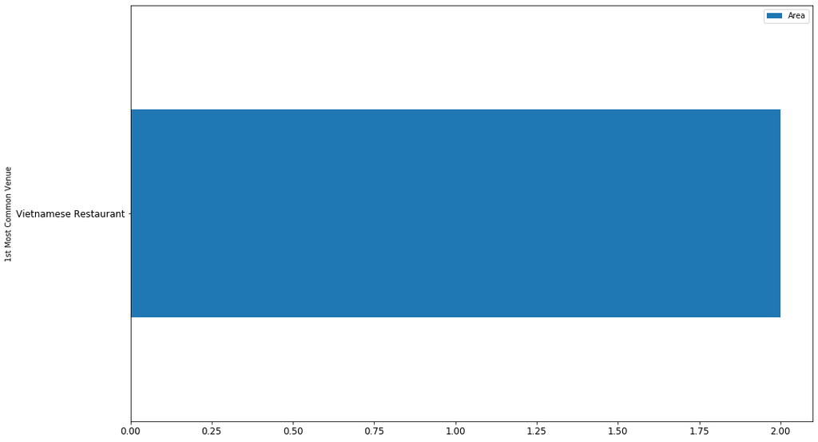

```python
cluster_16 = show_cluster_inf(hcmc_venues_merged, 15, 5)
```

```python
cluster_16
```

|  | Area | Cluster Labels | 1st Most Common Venue | 2nd Most Common Venue | 3rd Most Common Venue | 4th Most Common Venue | 5th Most Common Venue | 6th Most Common Venue | 7th Most Common Venue | 8th Most Common Venue | 9th Most Common Venue | 10th Most Common Venue | 11th Most Common Venue | 12th Most Common Venue | 13th Most Common Venue | 14th Most Common Venue | 15th Most Common Venue | 16th Most Common Venue | 17th Most Common Venue | 18th Most Common Venue | 19th Most Common Venue | 20th Most Common Venue |
| --- | --- | --- | --- | --- | --- | --- | --- | --- | --- | --- | --- | --- | --- | --- | --- | --- | --- | --- | --- | --- | --- | --- |
| 8 | Phường Nguyễn Cư Trinh, Quận 1 | 15.0 | Vietnamese Restaurant | Café | Seafood Restaurant | Asian Restaurant | Hotel | Bookstore | Dessert Shop | Japanese Restaurant | Vegetarian / Vegan Restaurant | Bakery | Bar | Convenience Store | Fast Food Restaurant | Spa | Hotpot Restaurant | Ice Cream Shop | Multiplex | Noodle House | Restaurant | Korean Restaurant |
| 9 | Phường Cầu Kho, Quận 1 | 15.0 | Vietnamese Restaurant | Café | Asian Restaurant | Seafood Restaurant | Food | Spa | Restaurant | Bookstore | Convenience Store | Hotpot Restaurant | Dessert Shop | Fast Food Restaurant | Supermarket | BBQ Joint | Bakery | Bar | Breakfast Spot | Thai Restaurant | Chinese Restaurant | Hotel |

###### Cluster 17

```
Number of Area in the cluster: 2
```

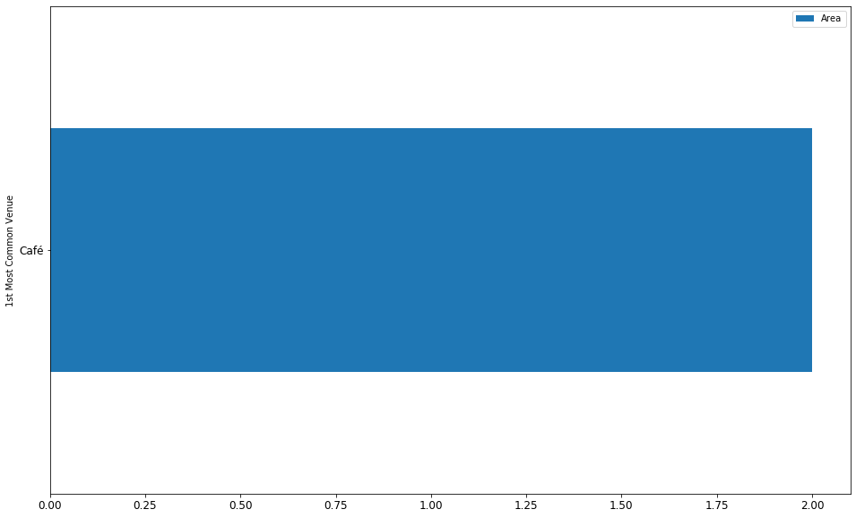

```python
cluster_17 = show_cluster_inf(hcmc_venues_merged, 16, 5)
```

```python
cluster_17
```

|  | Area | Cluster Labels | 1st Most Common Venue | 2nd Most Common Venue | 3rd Most Common Venue | 4th Most Common Venue | 5th Most Common Venue | 6th Most Common Venue | 7th Most Common Venue | 8th Most Common Venue | 9th Most Common Venue | 10th Most Common Venue | 11th Most Common Venue | 12th Most Common Venue | 13th Most Common Venue | 14th Most Common Venue | 15th Most Common Venue | 16th Most Common Venue | 17th Most Common Venue | 18th Most Common Venue | 19th Most Common Venue | 20th Most Common Venue |
| --- | --- | --- | --- | --- | --- | --- | --- | --- | --- | --- | --- | --- | --- | --- | --- | --- | --- | --- | --- | --- | --- | --- |
| 111 | Phường 7, Quận Phú Nhuận | 16.0 | Café | Vietnamese Restaurant | Fast Food Restaurant | Vegetarian / Vegan Restaurant | Korean Restaurant | Food | Hotpot Restaurant | Japanese Restaurant | Ice Cream Shop | Supermarket | Restaurant | Thai Restaurant | Asian Restaurant | Market | Seafood Restaurant | BBQ Joint | Bakery | Bar | Bookstore | Breakfast Spot |
| 114 | Phường 2, Quận Phú Nhuận | 16.0 | Café | Vietnamese Restaurant | Asian Restaurant | Fast Food Restaurant | Food | Restaurant | Japanese Restaurant | Supermarket | Korean Restaurant | Thai Restaurant | Steakhouse | Hotpot Restaurant | Vegetarian / Vegan Restaurant | Ice Cream Shop | Spa | Pizza Place | Snack Place | Market | BBQ Joint | Bakery |

###### Cluster 18

```
Number of Area in the cluster: 10
```

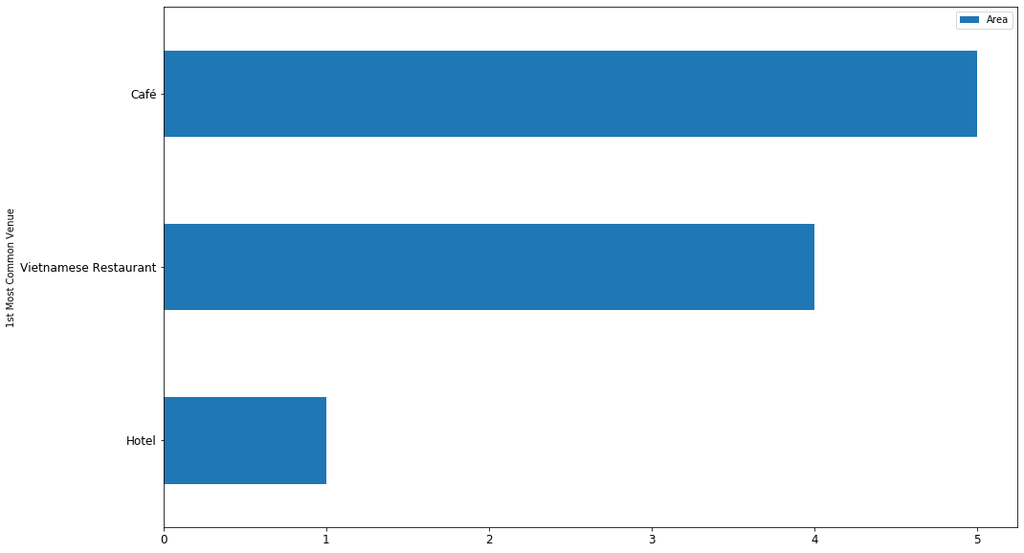

```python
cluster_18 = show_cluster_inf(hcmc_venues_merged, 17, 5)
```

```python
cluster_18
```

|  | Area | Cluster Labels | 1st Most Common Venue | 2nd Most Common Venue | 3rd Most Common Venue | 4th Most Common Venue | 5th Most Common Venue | 6th Most Common Venue | 7th Most Common Venue | 8th Most Common Venue | 9th Most Common Venue | 10th Most Common Venue | 11th Most Common Venue | 12th Most Common Venue | 13th Most Common Venue | 14th Most Common Venue | 15th Most Common Venue | 16th Most Common Venue | 17th Most Common Venue | 18th Most Common Venue | 19th Most Common Venue | 20th Most Common Venue |
| --- | --- | --- | --- | --- | --- | --- | --- | --- | --- | --- | --- | --- | --- | --- | --- | --- | --- | --- | --- | --- | --- | --- |
| 31 | Phường Bình Thọ, Quận Thủ Đức | 17.0 | Café | Asian Restaurant | Restaurant | Korean Restaurant | Hotel | BBQ Joint | Bakery | Bar | Bookstore | Breakfast Spot | Chinese Restaurant | Convenience Store | Dessert Shop | Fast Food Restaurant | Food | Gym / Fitness Center | Vietnamese Restaurant | Hotpot Restaurant | Vegetarian / Vegan Restaurant | Japanese Restaurant |
| 36 | Phường Hiệp Phú, Quận 9 | 17.0 | Vietnamese Restaurant | Convenience Store | Fast Food Restaurant | Korean Restaurant | Hotpot Restaurant | BBQ Joint | Bakery | Bar | Bookstore | Breakfast Spot | Café | Chinese Restaurant | Dessert Shop | Food | Gym / Fitness Center | Hotel | Ice Cream Shop | Vegetarian / Vegan Restaurant | Japanese Restaurant | Market |
| 82 | Phường 2, Quận Tân Bình | 17.0 | Café | Vietnamese Restaurant | Japanese Restaurant | Hotel | Seafood Restaurant | Korean Restaurant | Thai Restaurant | Pizza Place | Bakery | Bar | Bookstore | Breakfast Spot | Food | BBQ Joint | Chinese Restaurant | Convenience Store | Dessert Shop | Fast Food Restaurant | Ice Cream Shop | Gym / Fitness Center |
| 83 | Phường 4, Quận Tân Bình | 17.0 | Café | Vietnamese Restaurant | Seafood Restaurant | Korean Restaurant | Pizza Place | Fast Food Restaurant | Asian Restaurant | Snack Place | Restaurant | BBQ Joint | Bakery | Bar | Bookstore | Breakfast Spot | Thai Restaurant | Chinese Restaurant | Convenience Store | Dessert Shop | Supermarket | Food |
| 118 | Phường 11, Quận Phú Nhuận | 17.0 | Café | Vietnamese Restaurant | Chinese Restaurant | Hotel | Asian Restaurant | BBQ Joint | Restaurant | Bakery | Bar | Breakfast Spot | Korean Restaurant | Japanese Restaurant | Convenience Store | Spa | Fast Food Restaurant | Bookstore | Thai Restaurant | Supermarket | Dessert Shop | Gym / Fitness Center |
| 139 | Phường 13, Quận 3 | 17.0 | Vietnamese Restaurant | Café | Restaurant | Breakfast Spot | Fast Food Restaurant | Hotel | Korean Restaurant | Asian Restaurant | Seafood Restaurant | Steakhouse | BBQ Joint | Bakery | Bar | Bookstore | Thai Restaurant | Supermarket | Chinese Restaurant | Convenience Store | Dessert Shop | Food |
| 141 | Phường 9, Quận 3 | 17.0 | Vietnamese Restaurant | Café | Seafood Restaurant | Korean Restaurant | BBQ Joint | Bar | Breakfast Spot | Hotel | Asian Restaurant | Pizza Place | Noodle House | Thai Restaurant | Bakery | Supermarket | Bookstore | Steakhouse | Spa | Chinese Restaurant | Convenience Store | Dessert Shop |
| 153 | Phường 10, Quận 10 | 17.0 | Café | Vietnamese Restaurant | Dessert Shop | Multiplex | Bookstore | Fast Food Restaurant | Korean Restaurant | Market | Ice Cream Shop | Spa | Seafood Restaurant | Asian Restaurant | Restaurant | Convenience Store | BBQ Joint | Bakery | Bar | Thai Restaurant | Breakfast Spot | Supermarket |
| 189 | Phường 3, Quận 4 | 17.0 | Vietnamese Restaurant | Seafood Restaurant | Café | Food | Korean Restaurant | Pizza Place | Restaurant | Asian Restaurant | Snack Place | Fast Food Restaurant | BBQ Joint | Bakery | Bar | Bookstore | Breakfast Spot | Thai Restaurant | Chinese Restaurant | Convenience Store | Dessert Shop | Supermarket |
| 256 | Phường Tân Phú, Quận 7 | 17.0 | Hotel | Café | Japanese Restaurant | Korean Restaurant | Market | Multiplex | Restaurant | Vietnamese Restaurant | Breakfast Spot | Food | Convenience Store | Bookstore | Bar | Bakery | BBQ Joint | Dessert Shop | Fast Food Restaurant | Chinese Restaurant | Ice Cream Shop | Gym / Fitness Center |

###### Cluster 19

```
Number of Area in the cluster: 13
```

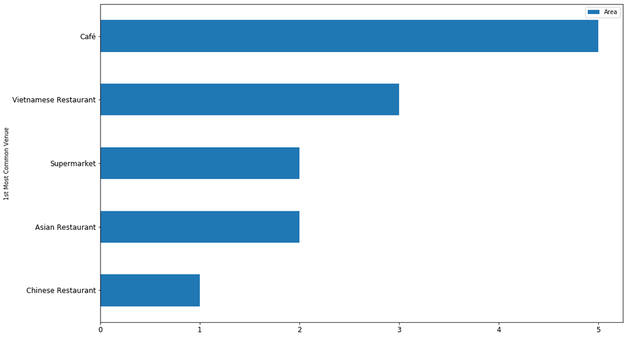

```python
cluster_19 = show_cluster_inf(hcmc_venues_merged, 18, 5)
```

```python
cluster_19
```

|  | Area | Cluster Labels | 1st Most Common Venue | 2nd Most Common Venue | 3rd Most Common Venue | 4th Most Common Venue | 5th Most Common Venue | 6th Most Common Venue | 7th Most Common Venue | 8th Most Common Venue | 9th Most Common Venue | 10th Most Common Venue | 11th Most Common Venue | 12th Most Common Venue | 13th Most Common Venue | 14th Most Common Venue | 15th Most Common Venue | 16th Most Common Venue | 17th Most Common Venue | 18th Most Common Venue | 19th Most Common Venue | 20th Most Common Venue |
| --- | --- | --- | --- | --- | --- | --- | --- | --- | --- | --- | --- | --- | --- | --- | --- | --- | --- | --- | --- | --- | --- | --- |
| 12 | Phường Hiệp Thành, Quận 12 | 18.0 | Vietnamese Restaurant | Supermarket | Market | Hotel | BBQ Joint | Bakery | Bar | Bookstore | Breakfast Spot | Café | Chinese Restaurant | Convenience Store | Dessert Shop | Fast Food Restaurant | Food | Gym / Fitness Center | Ice Cream Shop | Hotpot Restaurant | Vegetarian / Vegan Restaurant | Japanese Restaurant |
| 55 | Phường 7, Quận Gò Vấp | 18.0 | Supermarket | Asian Restaurant | Café | Hotpot Restaurant | BBQ Joint | Bakery | Bar | Bookstore | Breakfast Spot | Chinese Restaurant | Convenience Store | Dessert Shop | Fast Food Restaurant | Food | Gym / Fitness Center | Hotel | Vietnamese Restaurant | Vegetarian / Vegan Restaurant | Japanese Restaurant | Korean Restaurant |
| 74 | Phường 2, Quận Bình Thạnh | 18.0 | Asian Restaurant | Café | Fast Food Restaurant | Supermarket | Seafood Restaurant | Restaurant | Market | Noodle House | Dessert Shop | Convenience Store | Chinese Restaurant | Breakfast Spot | Gym / Fitness Center | Bookstore | Bar | Bakery | BBQ Joint | Food | Vietnamese Restaurant | Hotel |
| 75 | Phường 1, Quận Bình Thạnh | 18.0 | Asian Restaurant | Seafood Restaurant | Fast Food Restaurant | Market | Café | Noodle House | Pizza Place | Supermarket | BBQ Joint | Bookstore | Breakfast Spot | Gym / Fitness Center | Bar | Bakery | Chinese Restaurant | Convenience Store | Dessert Shop | Food | Vietnamese Restaurant | Hotel |
| 103 | Phường Phú Thạnh, Quận Tân Phú | 18.0 | Café | Supermarket | Fast Food Restaurant | Vietnamese Restaurant | Hotpot Restaurant | BBQ Joint | Bakery | Bar | Bookstore | Breakfast Spot | Chinese Restaurant | Convenience Store | Dessert Shop | Food | Gym / Fitness Center | Hotel | Ice Cream Shop | Vegetarian / Vegan Restaurant | Japanese Restaurant | Korean Restaurant |
| 106 | Phường Hiệp Tân, Quận Tân Phú | 18.0 | Supermarket | Café | Food | Vietnamese Restaurant | Hotpot Restaurant | BBQ Joint | Bakery | Bar | Bookstore | Breakfast Spot | Chinese Restaurant | Convenience Store | Dessert Shop | Fast Food Restaurant | Gym / Fitness Center | Hotel | Ice Cream Shop | Vegetarian / Vegan Restaurant | Japanese Restaurant | Korean Restaurant |
| 148 | Phường 15, Quận 10 | 18.0 | Vietnamese Restaurant | Café | Seafood Restaurant | Restaurant | Bakery | Food | Hotpot Restaurant | Noodle House | Asian Restaurant | Supermarket | Pizza Place | Snack Place | BBQ Joint | Thai Restaurant | Bar | Bookstore | Breakfast Spot | Chinese Restaurant | Convenience Store | Dessert Shop |
| 159 | Phường 7, Quận 10 | 18.0 | Café | Asian Restaurant | BBQ Joint | Supermarket | Bookstore | Chinese Restaurant | Hotpot Restaurant | Bakery | Bar | Breakfast Spot | Convenience Store | Dessert Shop | Fast Food Restaurant | Food | Gym / Fitness Center | Hotel | Vietnamese Restaurant | Vegetarian / Vegan Restaurant | Japanese Restaurant | Korean Restaurant |
| 161 | Phường 6, Quận 10 | 18.0 | Café | Asian Restaurant | Fast Food Restaurant | BBQ Joint | Supermarket | Chinese Restaurant | Dessert Shop | Vegetarian / Vegan Restaurant | Hotel | Bakery | Bar | Bookstore | Breakfast Spot | Convenience Store | Food | Gym / Fitness Center | Vietnamese Restaurant | Hotpot Restaurant | Japanese Restaurant | Korean Restaurant |
| 173 | Phường 7, Quận 11 | 18.0 | Chinese Restaurant | Café | Asian Restaurant | BBQ Joint | Bookstore | Vietnamese Restaurant | Supermarket | Snack Place | Food | Thai Restaurant | Bakery | Bar | Breakfast Spot | Steakhouse | Spa | Convenience Store | Dessert Shop | Fast Food Restaurant | Gym / Fitness Center | Seafood Restaurant |
| 215 | Phường 11, Quận 6 | 18.0 | Café | Asian Restaurant | Supermarket | Hotpot Restaurant | BBQ Joint | Bakery | Bar | Bookstore | Breakfast Spot | Chinese Restaurant | Convenience Store | Dessert Shop | Fast Food Restaurant | Food | Gym / Fitness Center | Hotel | Vietnamese Restaurant | Vegetarian / Vegan Restaurant | Japanese Restaurant | Korean Restaurant |
| 231 | Phường 13, Quận 8 | 18.0 | Café | Chinese Restaurant | Food | Supermarket | Noodle House | Vietnamese Restaurant | Hotel | BBQ Joint | Bakery | Bar | Bookstore | Breakfast Spot | Convenience Store | Dessert Shop | Fast Food Restaurant | Gym / Fitness Center | Ice Cream Shop | Hotpot Restaurant | Vegetarian / Vegan Restaurant | Japanese Restaurant |
| 234 | Phường 14, Quận 8 | 18.0 | Vietnamese Restaurant | Supermarket | Chinese Restaurant | Hotpot Restaurant | BBQ Joint | Bakery | Bar | Bookstore | Breakfast Spot | Café | Convenience Store | Dessert Shop | Fast Food Restaurant | Food | Gym / Fitness Center | Hotel | Ice Cream Shop | Vegetarian / Vegan Restaurant | Japanese Restaurant | Korean Restaurant |

## Discussion

After reviewing through horizontal bar-chart and table representing top-twenty common venues of each cluster (shown above or shown below the conclusion section), it is interestedly found that Café and Vietnamese Restaurant are most common venues in Ho Chi Minh City. This finding coincides Vietnamese habits and what we can see on the streets here. food services and chains of coffee shop are emerging business in Vietnam and competition in this sector is quite tough. As a result, as an investor, you should take into consideration if you would like to establish your business in this sector.

Café and/or Vietnamese Restaurant are the most venues found in the Clusters 1, 4, 12, 13, 16, 17. As a result, there is an opportunity for investors who would like to open a business other than Café.

Bar is the most common venue found in the Cluster 9. This area is located at center of the city, where we can find many services for tourists. As a result, in role of a tourist, you can take a visit here to spend you stay with lots of attractive destinations for tourists. In a contrary, opening a business related to Bar in this location should be carefully considered.

Buzzing Pham Ngu Lao is centered on backpacker hotspot Bùi Viện street, where homestyle Vietnamese eateries sit next to tiny shops offering souvenirs, clothing, and tattoos. A raucous nightlife scene includes sidewalk beer cafes and back-alley dive bars, plus cocktail spots and dance clubs. This location is classified in the Cluster 3, where Hotel is one of the most common venues found in this cluster. The finding interestingly reflects the correlation between the real life and the outcome of data science.

Seafood Restaurants are found in the Cluster 5. The finding would give a useful information to ones who are fan of seafoods. If you would like to be a seafood supplier, please take into account this useful information.

## Conclusion

In conclusion, through this project, with help of various packages and libraries, especially Pandas, sklearn, matplotlib and folium, a data relating to common venues of neighborhoods in Ho Chi Minh City is collected, processed and classified.

An examination of clusters obtained by using K-means clustering algorithm allows a better understanding about areas of Ho Chi Minh City in considering as destinations for various purposes, such as investments, tourists, culture-research, etc. It is interestingly found that some clusters represent a good correlation between what we can see in a real life and what can be obtained from algorithm of data science.

A deeper digging to the clustered data should be perspectively carried out to get a better insight of neighborhoods in Ho Chi Minh City.

#### Note

In case the folium map is not correctly shown above, please kindly review it here

```python
from IPython.display import IFrame
IFrame(src='hcmc_map.html', width=900, height=600)
```

[interactive chart not shown]